# W3cubDocs

## DISTINCT()

Returns the list of unique field values.

### Syntax

```
SELECT DISTINCT( [ * | <field_key> | /<regular_expression>/ ] ) FROM_clause [WHERE_clause] [GROUP_BY_clause] [ORDER_BY_clause] [LIMIT_clause] [OFFSET_clause] [SLIMIT_clause] [SOFFSET_clause]
```

#### Nested Syntax

```
SELECT COUNT(DISTINCT( [ * | <field_key> | /<regular_expression>/ ] )) [...]
```

### Description of Syntax

`DISTINCT(field_key)` Returns the unique field values associated with the field key.

`DISTINCT(/regular_expression/)` Returns the unique field values associated with each field key that matches the regular expression.

`DISTINCT(*)` Returns the unique field values associated with each field key in the measurement.

`DISTINCT()` supports all field value data types. InfluxQL supports nesting `DISTINCT()` with `COUNT()`.

### Examples

#### Example 1: List the distinct field values associated with a field key

```
> SELECT DISTINCT("level description") FROM "h2o_feet"

name: h2o_feet
time                   distinct
----                   --------
1970-01-01T00:00:00Z   between 6 and 9 feet
1970-01-01T00:00:00Z   below 3 feet
1970-01-01T00:00:00Z   between 3 and 6 feet
1970-01-01T00:00:00Z   at or greater than 9 feet
```

The query returns a tabular list of the unique field values in the `level description` field key in the `h2o_feet` measurement.

#### Example 2: List the distinct field values associated with each field key in a measurement

```
> SELECT DISTINCT(*) FROM "h2o_feet"

name: h2o_feet
time                   distinct_level description   distinct_water_level
----                   --------------------------   --------------------
1970-01-01T00:00:00Z   between 6 and 9 feet         8.12
1970-01-01T00:00:00Z   between 3 and 6 feet         8.005
1970-01-01T00:00:00Z   at or greater than 9 feet    7.887
1970-01-01T00:00:00Z   below 3 feet                 7.762
[...]
```

The query returns a tabular list of the unique field values for each field key in the `h2o_feet` measurement. The `h2o_feet` measurement has two field keys: `level description` and `water_level`.

#### Example 3: List the distinct field values associated with each field key that matches a regular expression

```
> SELECT DISTINCT(/description/) FROM "h2o_feet"

name: h2o_feet
time                   distinct_level description
----                   --------------------------
1970-01-01T00:00:00Z   below 3 feet
1970-01-01T00:00:00Z   between 6 and 9 feet
1970-01-01T00:00:00Z   between 3 and 6 feet
1970-01-01T00:00:00Z   at or greater than 9 feet
```

The query returns a tabular list of the unique field values for each field key in the `h2o_feet` measurement that contains the word `description`.

#### Example 4: List the distinct field values associated with a field key and include several clauses

```
>  SELECT DISTINCT("level description") FROM "h2o_feet" WHERE time >= '2015-08-17T23:48:00Z' AND time <= '2015-08-18T00:54:00Z' GROUP BY time(12m),* SLIMIT 1

name: h2o_feet
tags: location=coyote_creek
time                   distinct
----                   --------
2015-08-18T00:00:00Z   between 6 and 9 feet
2015-08-18T00:12:00Z   between 6 and 9 feet
2015-08-18T00:24:00Z   between 6 and 9 feet
2015-08-18T00:36:00Z   between 6 and 9 feet
2015-08-18T00:48:00Z   between 6 and 9 feet
```

The query returns a tabular list of the unique field values in the `level description` field key. It covers the time range between `2015-08-17T23:48:00Z` and `2015-08-18T00:54:00Z` and groups results into 12-minute time intervals and per tag. The query also limits the number of series returned to one.

#### Example 5: Count the distinct field values associated with a field key

```
> SELECT COUNT(DISTINCT("level description")) FROM "h2o_feet"

name: h2o_feet
time                   count
----                   -----
1970-01-01T00:00:00Z   4
```

The query returns the number of unique field values in the `level description` field key and the `h2o_feet` measurement.

### Common Issues with DISTINCT()

#### Issue 1: DISTINCT() and the INTO clause

Using `DISTINCT()` with the `INTO` clause can cause InfluxDB to overwrite points in the destination measurement. `DISTINCT()` often returns several results with the same timestamp; InfluxDB assumes points with the same series and timestamp are duplicate points and simply overwrites any duplicate point with the most recent point in the destination measurement.

##### Example

The first query in the codeblock below uses the `DISTINCT()` function and returns four results. Notice that each result has the same timestamp. The second query adds an `INTO` clause to the initial query and writes the query results to the `distincts` measurement. The last query in the codeblock selects all the data in the `distincts` measurement.

The last query returns one point because the four initial results are duplicate points; they belong to the same series and have the same timestamp. When the system encounters duplicate points, it simply overwrites the previous point with the most recent point.

```
>  SELECT DISTINCT("level description") FROM "h2o_feet"

name: h2o_feet
time                   distinct
----                   --------
1970-01-01T00:00:00Z   below 3 feet
1970-01-01T00:00:00Z   between 6 and 9 feet
1970-01-01T00:00:00Z   between 3 and 6 feet
1970-01-01T00:00:00Z   at or greater than 9 feet

>  SELECT DISTINCT("level description") INTO "distincts" FROM "h2o_feet"

name: result
time                   written
----                   -------
1970-01-01T00:00:00Z   4

> SELECT * FROM "distincts"

name: distincts
time                   distinct
----                   --------
1970-01-01T00:00:00Z   at or greater than 9 feet
```

## INTEGRAL()

Returns the area under the curve for subsequent field values.

### Syntax

```
SELECT INTEGRAL( [ * | <field_key> | /<regular_expression>/ ] [ , <unit> ]  ) [INTO_clause] FROM_clause [WHERE_clause] [GROUP_BY_clause] [ORDER_BY_clause] [LIMIT_clause] [OFFSET_clause] [SLIMIT_clause] [SOFFSET_clause]
```

### Description of Syntax

InfluxDB calculates the area under the curve for subsequent field values and converts those results into the summed area per `unit`. The `unit` argument is an integer followed by a duration literal and it is optional. If the query does not specify the `unit`, the unit defaults to one second (`1s`).

`INTEGRAL(field_key)` Returns the area under the curve for subsequent field values assoicated with the field key.

`INTEGRAL(/regular_expression/)` Returns the are under the curve for subsequent field values associated with each field key that matches the regular expression.

`INTEGRAL()` does not support `fill()`. `INTEGRAL()` supports int64 and float64 field value data types.

### Examples

Examples 1-5 use the following subsample of the `NOAA_water_database` data:

```
> SELECT "water_level" FROM "h2o_feet" WHERE "location" = 'santa_monica' AND time >= '2015-08-18T00:00:00Z' AND time <= '2015-08-18T00:30:00Z'

name: h2o_feet
time                   water_level
----                   -----------
2015-08-18T00:00:00Z   2.064
2015-08-18T00:06:00Z   2.116
2015-08-18T00:12:00Z   2.028
2015-08-18T00:18:00Z   2.126
2015-08-18T00:24:00Z   2.041
2015-08-18T00:30:00Z   2.051
```

#### Example 1: Calculate the integral for the field values associated with a field key

```
> SELECT INTEGRAL("water_level") FROM "h2o_feet" WHERE "location" = 'santa_monica' AND time >= '2015-08-18T00:00:00Z' AND time <= '2015-08-18T00:30:00Z'

name: h2o_feet
time                 integral
----                 --------
1970-01-01T00:00:00Z 3732.66
```

The query returns the area under the curve (in seconds) for the field values associated with the `water_level` field key and in the `h2o_feet` measurement.

#### Example 2: Calculate the integral for the field values associated with a field key and specify the unit option

```
> SELECT INTEGRAL("water_level",1m) FROM "h2o_feet" WHERE "location" = 'santa_monica' AND time >= '2015-08-18T00:00:00Z' AND time <= '2015-08-18T00:30:00Z'

name: h2o_feet
time                 integral
----                 --------
1970-01-01T00:00:00Z 62.211
```

The query returns the area under the curve (in minutes) for the field values associated with the `water_level` field key and in the `h2o_feet` measurement.

#### Example 3: Calculate the integral for the field values associated with each field key in a measurement and specify the unit option

```
> SELECT INTEGRAL(*,1m) FROM "h2o_feet" WHERE "location" = 'santa_monica' AND time >= '2015-08-18T00:00:00Z' AND time <= '2015-08-18T00:30:00Z'

name: h2o_feet
time                 integral_water_level
----                 --------------------
1970-01-01T00:00:00Z 62.211
```

The query returns the area under the curve (in minutes) for the field values associated with each field key that stores numerical values in the `h2o_feet` measurement. The `h2o_feet` measurement has on numerical field: `water_level`.

#### Example 4: Calculate the integral for the field values associated with each field key that matches a regular expression and specify the unit option

```
> SELECT INTEGRAL(/water/,1m) FROM "h2o_feet" WHERE "location" = 'santa_monica' AND time >= '2015-08-18T00:00:00Z' AND time <= '2015-08-18T00:30:00Z'

name: h2o_feet
time                 integral_water_level
----                 --------------------
1970-01-01T00:00:00Z 62.211
```

The query returns the area under the curve (in minutes) for the field values associated with each field key that stores numerical values includes the word `water` in the `h2o_feet` measurement.

#### Example 5: Calculate the integral for the field values associated with a field key and include several clauses

```
> SELECT INTEGRAL("water_level",1m) FROM "h2o_feet" WHERE "location" = 'santa_monica' AND time >= '2015-08-18T00:00:00Z' AND time <= '2015-08-18T00:30:00Z' GROUP BY time(12m) LIMIT 1

name: h2o_feet
time                 integral
----                 --------
2015-08-18T00:00:00Z 24.972
```

The query returns the area under the curve (in minutes) for the field values associated with the `water_level` field key and in the `h2o_feet` measurement. It covers the time range between `2015-08-18T00:00:00Z` and `2015-08-18T00:30:00Z`, groups results into 12-minute intervals, and limits the number of results returned to one.

## MEAN()

Returns the arithmetic mean (average) of field values.

### Syntax

```
SELECT MEAN( [ * | <field_key> | /<regular_expression>/ ] ) [INTO_clause] FROM_clause [WHERE_clause] [GROUP_BY_clause] [ORDER_BY_clause] [LIMIT_clause] [OFFSET_clause] [SLIMIT_clause] [SOFFSET_clause]
```

### Description of Syntax

`MEAN(field_key)` Returns the average field value associated with the field key.

`MEAN(/regular_expression/)` Returns the average field value associated with each field key that matches the regular expression.

`MEAN(*)` Returns the average field value associated with each field key in the measurement.

`MEAN()` supports int64 and float64 field value data types.

### Examples

#### Example 1: Calculate the mean field value associated with a field key

```
> SELECT MEAN("water_level") FROM "h2o_feet"

name: h2o_feet
time                   mean
----                   ----
1970-01-01T00:00:00Z   4.442107025822522
```

The query returns the average field value in the `water_level` field key in the `h2o_feet` measurement.

#### Example 2: Calculate the mean field value associated with each field key in a measurement

```
> SELECT MEAN(*) FROM "h2o_feet"

name: h2o_feet
time                   mean_water_level
----                   ----------------
1970-01-01T00:00:00Z   4.442107025822522
```

The query returns the average field value for every field key that stores numerical values in the `h2o_feet` measurement. The `h2o_feet` measurement has one numerical field: `water_level`.

#### Example 3: Calculate the mean field value associated with each field key that matches a regular expression

```
> SELECT MEAN(/water/) FROM "h2o_feet"

name: h2o_feet
time                   mean_water_level
----                   ----------------
1970-01-01T00:00:00Z   4.442107025822523
```

The query returns the average field value for each field key that stores numerical values and includes the word `water` in the `h2o_feet` measurement.

#### Example 4: Calculate the mean field value associated with a field key and include several clauses

```
> SELECT MEAN("water_level") FROM "h2o_feet" WHERE time >= '2015-08-17T23:48:00Z' AND time <= '2015-08-18T00:54:00Z' GROUP BY time(12m),* fill(9.01) LIMIT 7 SLIMIT 1

name: h2o_feet
tags: location=coyote_creek
time                   mean
----                   ----
2015-08-17T23:48:00Z   9.01
2015-08-18T00:00:00Z   8.0625
2015-08-18T00:12:00Z   7.8245
2015-08-18T00:24:00Z   7.5675
2015-08-18T00:36:00Z   7.303
2015-08-18T00:48:00Z   7.046
```

The query returns the average of the values in the `water_level` field key. It covers the time range between `2015-08-17T23:48:00Z` and `2015-08-18T00:54:00Z` and groups results into 12-minute time intervals and per tag. The query fills empty time intervals with `9.01` and limits the number of points and series returned to seven and one.

## MEDIAN()

Returns the middle value from a sorted list of field values.

### Syntax

```
SELECT MEDIAN( [ * | <field_key> | /<regular_expression>/ ] ) [INTO_clause] FROM_clause [WHERE_clause] [GROUP_BY_clause] [ORDER_BY_clause] [LIMIT_clause] [OFFSET_clause] [SLIMIT_clause] [SOFFSET_clause]
```

### Description of Syntax

`MEDIAN(field_key)` Returns the middle field value associated with the field key.

`MEDIAN(/regular_expression/)` Returns the middle field value associated with each field key that matches the regular expression.

`MEDIAN(*)` Returns the middle field value associated with each field key in the measurement.

`MEDIAN()` supports int64 and float64 field value data types.

> **Note:** `MEDIAN()` is nearly equivalent to `PERCENTILE(field_key, 50)`, except `MEDIAN()` returns the average of the two middle field values if the field contains an even number of values.

### Examples

#### Example 1: Calculate the median field value associated with a field key

```
> SELECT MEDIAN("water_level") FROM "h2o_feet"

name: h2o_feet
time                   median
----                   ------
1970-01-01T00:00:00Z   4.124
```

The query returns the middle field value in the `water_level` field key and in the `h2o_feet` measurement.

#### Example 2: Calculate the median field value associated with each field key in a measurement

```
> SELECT MEDIAN(*) FROM "h2o_feet"

name: h2o_feet
time                   median_water_level
----                   ------------------
1970-01-01T00:00:00Z   4.124
```

The query returns the middle field value for every field key that stores numerical values in the `h2o_feet` measurement. The `h2o_feet` measurement has one numerical field: `water_level`.

#### Example 3: Calculate the median field value associated with each field key that matches a regular expression

```
> SELECT MEDIAN(/water/) FROM "h2o_feet"

name: h2o_feet
time                   median_water_level
----                   ------------------
1970-01-01T00:00:00Z   4.124
```

The query returns the middle field value for every field key that stores numerical values and includes the word `water` in the `h2o_feet` measurement.

#### Example 4: Calculate the median field value associated with a field key and include several clauses

```
> SELECT MEDIAN("water_level") FROM "h2o_feet" WHERE time >= '2015-08-17T23:48:00Z' AND time <= '2015-08-18T00:54:00Z' GROUP BY time(12m),* fill(700) LIMIT 7 SLIMIT 1 SOFFSET 1

name: h2o_feet
tags: location=santa_monica
time                   median
----                   ------
2015-08-17T23:48:00Z   700
2015-08-18T00:00:00Z   2.09
2015-08-18T00:12:00Z   2.077
2015-08-18T00:24:00Z   2.0460000000000003
2015-08-18T00:36:00Z   2.0620000000000003
2015-08-18T00:48:00Z   700
```

The query returns the middle field value in the `water_level` field key. It covers the time range between `2015-08-17T23:48:00Z` and `2015-08-18T00:54:00Z` and groups results into 12-minute time intervals and per tag. The query fills empty time intervals with `700`, limits the number of points and series returned to seven and one, and offsets the series returned by one.

## MODE()

Returns the most frequent value in a list of field values.

### Syntax

```
SELECT MODE( [ * | <field_key> | /<regular_expression>/ ] ) [INTO_clause] FROM_clause [WHERE_clause] [GROUP_BY_clause] [ORDER_BY_clause] [LIMIT_clause] [OFFSET_clause] [SLIMIT_clause] [SOFFSET_clause]
```

### Description of Syntax

`MODE(field_key)` Returns the most frequent field value associated with the field key.

`MODE(/regular_expression/)` Returns the most frequent field value associated with each field key that matches the regular expression.

`MODE(*)` Returns the most frequent field value associated with each field key in the measurement.

`MODE()` supports all field value data types.

> **Note:** `MODE()` returns the field value with the earliest timestamp if there’s a tie between two or more values for the maximum number of occurrences.

### Examples

#### Example 1: Calculate the mode field value associated with a field key

```
> SELECT MODE("level description") FROM "h2o_feet"

name: h2o_feet
time                   mode
----                   ----
1970-01-01T00:00:00Z   between 3 and 6 feet
```

The query returns the most frequent field value in the `level description` field key and in the `h2o_feet` measurement.

#### Example 2: Calculate the mode field value associated with each field key in a measurement

```
> SELECT MODE(*) FROM "h2o_feet"

name: h2o_feet
time                   mode_level description   mode_water_level
----                   ----------------------   ----------------
1970-01-01T00:00:00Z   between 3 and 6 feet     2.69
```

The query returns the most frequent field value for every field key in the `h2o_feet` measurement. The `h2o_feet` measurement has two field keys: `level description` and `water_level`.

#### Example 3: Calculate the mode field value associated with each field key that matches a regular expression

```
> SELECT MODE(/water/) FROM "h2o_feet"

name: h2o_feet
time                   mode_water_level
----                   ----------------
1970-01-01T00:00:00Z   2.69
```

The query returns the most frequent field value for every field key that includes the word `/water/` in the `h2o_feet` measurement.

#### Example 4: Calculate the mode field value associated with a field key and include several clauses

```
> SELECT MODE("level description") FROM "h2o_feet" WHERE time >= '2015-08-17T23:48:00Z' AND time <= '2015-08-18T00:54:00Z' GROUP BY time(12m),* LIMIT 3 SLIMIT 1 SOFFSET 1

name: h2o_feet
tags: location=santa_monica
time                   mode
----                   ----
2015-08-17T23:48:00Z
2015-08-18T00:00:00Z   below 3 feet
2015-08-18T00:12:00Z   below 3 feet
```

## SPREAD()

Returns the difference between the minimum and maximum field values.

### Syntax

```
SELECT SPREAD( [ * | <field_key> | /<regular_expression>/ ] ) [INTO_clause] FROM_clause [WHERE_clause] [GROUP_BY_clause] [ORDER_BY_clause] [LIMIT_clause] [OFFSET_clause] [SLIMIT_clause] [SOFFSET_clause]
```

### Description of Syntax

`SPREAD(field_key)` Returns the difference between the minimum and maximum field values associated with the field key.

`SPREAD(/regular_expression/)` Returns the difference between the minimum and maximum field values associated with each field key that matches the regular expression.

`SPREAD(*)` Returns the difference between the minimum and maximum field values associated with each field key in the measurement.

`SPREAD()` supports int64 and float64 field value data types.

### Examples

#### Example 1: Calculate the spread for the field values associated with a field key

```
> SELECT SPREAD("water_level") FROM "h2o_feet"

name: h2o_feet
time                   spread
----                   ------
1970-01-01T00:00:00Z   10.574
```

The query returns the difference between the minimum and maximum field values in the `water_level` field key and in the `h2o_feet` measurement.

#### Example 2: Calculate the spread for the field values associated with each field key in a measurement

```
> SELECT SPREAD(*) FROM "h2o_feet"

name: h2o_feet
time                   spread_water_level
----                   ------------------
1970-01-01T00:00:00Z   10.574
```

The query returns the difference between the minimum and maximum field values for every field key that stores numerical values in the `h2o_feet` measurement. The `h2o_feet` measurement has one numerical field: `water_level`.

#### Example 3: Calculate the spread for the field values associated with each field key that matches a regular expression

```
> SELECT SPREAD(/water/) FROM "h2o_feet"

name: h2o_feet
time                   spread_water_level
----                   ------------------
1970-01-01T00:00:00Z   10.574
```

The query returns the difference between the minimum and maximum field values for every field key that stores numerical values and includes the word `water` in the `h2o_feet` measurement.

#### Example 4: Calculate the spread for the field values associated with a field key and include several clauses

```
> SELECT SPREAD("water_level") FROM "h2o_feet" WHERE time >= '2015-08-17T23:48:00Z' AND time <= '2015-08-18T00:54:00Z' GROUP BY time(12m),* fill(18) LIMIT 3 SLIMIT 1 SOFFSET 1

name: h2o_feet
tags: location=santa_monica
time                   spread
----                   ------
2015-08-17T23:48:00Z   18
2015-08-18T00:00:00Z   0.052000000000000046
2015-08-18T00:12:00Z   0.09799999999999986
```

The query returns the difference between the minimum and maximum field values in the `water_level` field key. It covers the time range between `2015-08-17T23:48:00Z` and `2015-08-18T00:54:00Z`and groups results into 12-minute time intervals and per tag. The query fills empty time intervals with `18`, limits the number of points and series returned to three and one, and offsets the series returned by one.

## STDDEV()

Returns the standard deviation of field values.

### Syntax

```
SELECT STDDEV( [ * | <field_key> | /<regular_expression>/ ] ) [INTO_clause] FROM_clause [WHERE_clause] [GROUP_BY_clause] [ORDER_BY_clause] [LIMIT_clause] [OFFSET_clause] [SLIMIT_clause] [SOFFSET_clause]
```

### Description of Syntax

`STDDEV(field_key)` Returns the standard deviation of field values associated with the field key.

`STDDEV(/regular_expression/)` Returns the standard deviation of field values associated with each field key that matches the regular expression.

`STDDEV(*)` Returns the standard deviation of field values associated with each field key in the measurement.

`STDDEV()` supports int64 and float64 field value data types.

### Examples

#### Example 1: Calculate the standard deviation for the field values associated with a field key

```
> SELECT STDDEV("water_level") FROM "h2o_feet"

name: h2o_feet
time                   stddev
----                   ------
1970-01-01T00:00:00Z   2.279144584196141
```

The query returns the standard deviation of the field values in the `water_level` field key and in the `h2o_feet` measurement.

#### Example 2: Calculate the standard deviation for the field values associated with each field key in a measurement

```
> SELECT STDDEV(*) FROM "h2o_feet"

name: h2o_feet
time                   stddev_water_level
----                   ------------------
1970-01-01T00:00:00Z   2.279144584196141
```

The query returns the standard deviation of the field values for each field key that stores numerical values in the `h2o_feet` measurement. The `h2o_feet` measurement has one numerical field: `water_level`.

#### Example 3: Calculate the standard deviation for the field values associated with each field key that matches a regular expression

```
> SELECT STDDEV(/water/) FROM "h2o_feet"

name: h2o_feet
time                   stddev_water_level
----                   ------------------
1970-01-01T00:00:00Z   2.279144584196141
```

The query returns the standard deviation of the field values for each field key that stores numerical values and includes the word `water` in the `h2o_feet` measurement.

#### Example 4: Calculate the standard deviation for the field values associated with a field key and include several clauses

```
> SELECT STDDEV("water_level") FROM "h2o_feet" WHERE time >= '2015-08-17T23:48:00Z' AND time <= '2015-08-18T00:54:00Z' GROUP BY time(12m),* fill(18000) LIMIT 2 SLIMIT 1 SOFFSET 1

name: h2o_feet
tags: location=santa_monica
time                   stddev
----                   ------
2015-08-17T23:48:00Z   18000
2015-08-18T00:00:00Z   0.03676955262170051
```

The query returns the standard deviation of the field values in the `water_level` field key. It covers the time range between `2015-08-17T23:48:00Z` and `2015-08-18T00:54:00Z` and groups results into 12-minute time intervals and per tag. The query fills empty time intervals with `18000`, limits the number of points and series returned to two and one, and offsets the series returned by one.

## SUM()

Returns the sum of field values.

### Syntax

```
SELECT SUM( [ * | <field_key> | /<regular_expression>/ ] ) [INTO_clause] FROM_clause [WHERE_clause] [GROUP_BY_clause] [ORDER_BY_clause] [LIMIT_clause] [OFFSET_clause] [SLIMIT_clause] [SOFFSET_clause]
```

### Description of Syntax

`SUM(field_key)` Returns the sum of field values associated with the field key.

`SUM(/regular_expression/)` Returns the sum of field values associated with each field key that matches the regular expression.

`SUM(*)` Returns the sums of field values associated with each field key in the measurement.

`SUM()` supports int64 and float64 field value data types.

### Examples:

#### Example 1: Calculate the sum of the field values associated with a field key

```
> SELECT SUM("water_level") FROM "h2o_feet"

name: h2o_feet
time                   sum
----                   ---
1970-01-01T00:00:00Z   67777.66900000004
```

The query returns the summed total of the field values in the `water_level` field key and in the `h2o_feet` measurement.

#### Example 2: Calculate the sum of the field values associated with each field key in a measurement

```
> SELECT SUM(*) FROM "h2o_feet"

name: h2o_feet
time                   sum_water_level
----                   ---------------
1970-01-01T00:00:00Z   67777.66900000004
```

The query returns the summed total of the field values for each field key that stores numerical values in the `h2o_feet` measurement. The `h2o_feet` measurement has one numerical field: `water_level`.

#### Example 3: Calculate the sum of the field values associated with each field key that matches a regular expression

```
> SELECT SUM(/water/) FROM "h2o_feet"

name: h2o_feet
time                   sum_water_level
----                   ---------------
1970-01-01T00:00:00Z   67777.66900000004
```

The query returns the summed total of the field values for each field key that stores numerical values and includes the word `water` in the `h2o_feet` measurement.

#### Example 4: Calculate the sum of the field values associated with a field key and include several clauses

```
> SELECT SUM("water_level") FROM "h2o_feet" WHERE time >= '2015-08-17T23:48:00Z' AND time <= '2015-08-18T00:54:00Z' GROUP BY time(12m),* fill(18000) LIMIT 4 SLIMIT 1

name: h2o_feet
tags: location=coyote_creek
time                   sum
----                   ---
2015-08-17T23:48:00Z   18000
2015-08-18T00:00:00Z   16.125
2015-08-18T00:12:00Z   15.649
2015-08-18T00:24:00Z   15.135
```

The query returns the summed total of the field values in the `water_level` field key. It covers the time range between `2015-08-17T23:48:00Z` and `2015-08-18T00:54:00Z` and groups results into 12-minute time intervals and per tag. The query fills empty time intervals with 18000, and it limits the number of points and series returned to four and one.

# Selectors

## BOTTOM()

Returns the smallest `N` field values.

### Syntax

```
SELECT BOTTOM(<field_key>[,<tag_key(s)>],<N> )[,<tag_key(s)>|<field_key(s)>] [INTO_clause] FROM_clause [WHERE_clause] [GROUP_BY_clause] [ORDER_BY_clause] [LIMIT_clause] [OFFSET_clause] [SLIMIT_clause] [SOFFSET_clause]
```

### Description of Syntax

`BOTTOM(field_key,N)` Returns the smallest N field values associated with the field key.

`BOTTOM(field_key,tag_key(s),N)` Returns the smallest field value for N tag values of the tag key.

`BOTTOM(field_key,N),tag_key(s),field_key(s)` Returns the smallest N field values associated with the field key in the parentheses and the relevant tag and/or field.

`BOTTOM()` supports int64 and float64 field value data types.

> **Notes:**
> - `BOTTOM()` returns the field value with the earliest timestamp if there’s a tie between two or more values for the smallest value.
> - `BOTTOM()` differs from other InfluxQL functions when combined with an `INTO` clause. See the Common Issues section for more information.

### Examples

#### Example 1: Select the bottom three field values associated with a field key

```
> SELECT BOTTOM("water_level",3) FROM "h2o_feet"

name: h2o_feet
time                   bottom
----                   ------
2015-08-29T14:30:00Z   -0.61
2015-08-29T14:36:00Z   -0.591
2015-08-30T15:18:00Z   -0.594
```

The query returns the smallest three field values in the `water_level` field key and in the `h2o_feet` measurement.

#### Example 2: Select the bottom field value associated with a field key for two tags

```
> SELECT BOTTOM("water_level","location",2) FROM "h2o_feet"

name: h2o_feet
time                   bottom   location
----                   ------   --------
2015-08-29T10:36:00Z   -0.243   santa_monica
2015-08-29T14:30:00Z   -0.61    coyote_creek
```

The query returns the smallest field values in the `water_level` field key for two tag values associated with the `location` tag key.

#### Example 3: Select the bottom four field values associated with a field key and the relevant tags and fields

```
> SELECT BOTTOM("water_level",4),"location","level description" FROM "h2o_feet"

name: h2o_feet
time                  bottom  location      level description
----                  ------  --------      -----------------
2015-08-29T14:24:00Z  -0.587  coyote_creek  below 3 feet
2015-08-29T14:30:00Z  -0.61   coyote_creek  below 3 feet
2015-08-29T14:36:00Z  -0.591  coyote_creek  below 3 feet
2015-08-30T15:18:00Z  -0.594  coyote_creek  below 3 feet
```

The query returns the smallest four field values in the `water_level` field key and the relevant values of the `location` tag key and the `level description` field key.

#### Example 4: Select the bottom three field values associated with a field key and include several clauses

```
> SELECT BOTTOM("water_level",3),"location" FROM "h2o_feet" WHERE time >= '2015-08-18T00:00:00Z' AND time <= '2015-08-18T00:54:00Z' GROUP BY time(24m) ORDER BY time DESC

name: h2o_feet
time                  bottom  location
----                  ------  --------
2015-08-18T00:48:00Z  1.991   santa_monica
2015-08-18T00:54:00Z  2.054   santa_monica
2015-08-18T00:54:00Z  6.982   coyote_creek
2015-08-18T00:24:00Z  2.041   santa_monica
2015-08-18T00:30:00Z  2.051   santa_monica
2015-08-18T00:42:00Z  2.057   santa_monica
2015-08-18T00:00:00Z  2.064   santa_monica
2015-08-18T00:06:00Z  2.116   santa_monica
2015-08-18T00:12:00Z  2.028   santa_monica
```

The query returns the smallest three values in the `water_level` field key for each 24-minute interval between `2015-08-18T00:00:00Z` and `2015-08-18T00:54:00Z`. It also returns results in descending timestamp order.

Notice that the GROUP BY time() clause does not override the points’ original timestamps. See Issue 1 in the section below for a more detailed explanation of that behavior.

### Common Issues with `BOTTOM()`

#### Issue 1: `BOTTOM()` with a `GROUP BY time()` clause

Queries with `BOTTOM()` and a `GROUP BY time()` clause return the specified number of points per `GROUP BY time()` interval. For most `GROUP BY time()` queries, the returned timestamps mark the start of the `GROUP BY time()` interval. `GROUP BY time()` queries with the `BOTTOM()` function behave differently; they maintain the timestamp of the original data point.

##### Example

The query below returns two points per 18-minute `GROUP BY time()` interval. Notice that the returned timestamps are the points’ original timestamps; they are not forced to match the start of the `GROUP BY time()` intervals.

```
> SELECT BOTTOM("water_level",2) FROM "h2o_feet" WHERE time >= '2015-08-18T00:00:00Z' AND time <= '2015-08-18T00:30:00Z' AND "location" = 'santa_monica' GROUP BY time(18m)

name: h2o_feet
time                   bottom
----                   ------
                           __
2015-08-18T00:00:00Z  2.064 |
2015-08-18T00:12:00Z  2.028 | <------- Smallest points for the first time interval
                           --
                           __
2015-08-18T00:24:00Z  2.041 |
2015-08-18T00:30:00Z  2.051 | <------- Smallest points for the second time interval
                           --
```

#### Issue 2: BOTTOM() and a tag key with fewer than N tag values

Queries with the syntax `SELECT BOTTOM(<field_key>,<tag_key>,<N>)` can return fewer points than expected. If the tag key has `X` tag values, the query specifies `N` values, and `X` is smaller than `N`, then the query returns `X` points.

##### Example

The query below asks for the smallest field values of `water_level` for three tag values of the `location` tag key. Because the `location` tag key has two tag values (`santa_monica` and `coyote_creek`), the query returns two points instead of three.

```
> SELECT BOTTOM("water_level","location",3) FROM "h2o_feet"

name: h2o_feet
time                   bottom   location
----                   ------   --------
2015-08-29T10:36:00Z   -0.243   santa_monica
2015-08-29T14:30:00Z   -0.61    coyote_creek
```

#### Issue 3: BOTTOM(), tags, and the INTO clause

When combined with an `INTO` clause and no `GROUP BY tag` clause, most InfluxQL functions convert any tags in the initial data to fields in the newly written data. This behavior also applies to the `BOTTOM()` function unless `BOTTOM()` includes a tag key as an argument: `BOTTOM(field_key,tag_key(s),N)`. In those cases, the system preserves the specified tag as a tag in the newly written data.

##### Example

The first query in the codeblock below returns the smallest field values in the `water_level` field key for two tag values associated with the `location` tag key. It also writes those results to the `bottom_water_levels` measurement.

The second query shows that InfluxDB preserved the `location` tag as a tag in the `bottom_water_levels` measurement.

```
> SELECT BOTTOM("water_level","location",2) INTO "bottom_water_levels" FROM "h2o_feet"

name: result
time                 written
----                 -------
1970-01-01T00:00:00Z 2

> SHOW TAG KEYS FROM "bottom_water_levels"

name: bottom_water_levels
tagKey
------
location
```

## FIRST()

Returns the field value with the oldest timestamp.

### Syntax

```
SELECT FIRST(<field_key>)[,<tag_key(s)>|<field_key(s)>] [INTO_clause] FROM_clause [WHERE_clause] [GROUP_BY_clause] [ORDER_BY_clause] [LIMIT_clause] [OFFSET_clause] [SLIMIT_clause] [SOFFSET_clause]
```

### Description of Syntax

`FIRST(field_key)` Returns the oldest field value (determined by timestamp) associated with the field key.

`FIRST(/regular_expression/)` Returns the oldest field value (determined by timestamp) associated with each field key that matches the regular expression.

`FIRST(*)` Returns the oldest field value (determined by timestamp) associated with each field key in the measurement.

`FIRST(field_key),tag_key(s),field_key(s)` Returns the oldest field value (determined by timestamp) associated with the field key in the parentheses and the relevant tag and/or field.

`FIRST()` supports all field value data types.

### Examples

#### Example 1: Select the first field value associated with a field key

```
> SELECT FIRST("level description") FROM "h2o_feet"

name: h2o_feet
time                   first
----                   -----
2015-08-18T00:00:00Z   between 6 and 9 feet
```

The query returns the oldest field value (determined by timestamp) associated with the `level description` field key and in the `h2o_feet` measurement.

#### Example 2: Select the first field value associated with each field key in a measurement

```
> SELECT FIRST(*) FROM "h2o_feet"

name: h2o_feet
time                   first_level description   first_water_level
----                   -----------------------   -----------------
1970-01-01T00:00:00Z   between 6 and 9 feet      8.12
```

The query returns the oldest field value (determined by timestamp) for each field key in the `h2o_feet` measurement. The `h2o_feet` measurement has two field keys: `level description` and `water_level`.

#### Example 3: Select the first field value associated with each field key that matches a regular expression

```
> SELECT FIRST(/level/) FROM "h2o_feet"

name: h2o_feet
time                   first_level description   first_water_level
----                   -----------------------   -----------------
1970-01-01T00:00:00Z   between 6 and 9 feet      8.12
```

The query returns the oldest field value for each field key that includes the word `level` in the `h2o_feet` measurement.

#### Example 4: Select the first value associated with a field key and the relevant tags and fields

```
> SELECT FIRST("level description"),"location","water_level" FROM "h2o_feet"

name: h2o_feet
time                  first                 location      water_level
----                  -----                 --------      -----------
2015-08-18T00:00:00Z  between 6 and 9 feet  coyote_creek  8.12
```

The query returns the oldest field value (determined by timestamp) in the `level description` field key and the relevant values of the `location` tag key and the `water_level` field key.

#### Example 5: Select the first field value associated with a field key and include several clauses

```
> SELECT FIRST("water_level") FROM "h2o_feet" WHERE time >= '2015-08-17T23:48:00Z' AND time <= '2015-08-18T00:54:00Z' GROUP BY time(12m),* fill(9.01) LIMIT 4 SLIMIT 1

name: h2o_feet
tags: location=coyote_creek
time                   first
----                   -----
2015-08-17T23:48:00Z   9.01
2015-08-18T00:00:00Z   8.12
2015-08-18T00:12:00Z   7.887
2015-08-18T00:24:00Z   7.635
```

The query returns the oldest field value (determined by timestamp) in the `water_level` field key. It covers the time range between `2015-08-17T23:48:00Z` and `2015-08-18T00:54:00Z` and groups results into 12-minute time intervals and per tag. The query fills empty time intervals with `9.01`, and it limits the number of points and series returned to four and one.

Notice that the `GROUP BY time()` clause overrides the points’ original timestamps. The timestamps in the results indicate the the start of each 12-minute time interval; the first point in the results covers the time interval between `2015-08-17T23:48:00Z` and just before `2015-08-18T00:00:00Z` and the last point in the results covers the time interval between `2015-08-18T00:24:00Z` and just before `2015-08-18T00:36:00Z`.

## LAST()

Returns the field value with the most recent timestamp.

### Syntax

```
SELECT LAST(<field_key>)[,<tag_key(s)>|<field_keys(s)>] [INTO_clause] FROM_clause [WHERE_clause] [GROUP_BY_clause] [ORDER_BY_clause] [LIMIT_clause] [OFFSET_clause] [SLIMIT_clause] [SOFFSET_clause]
```

### Description of Syntax

`LAST(field_key)` Returns the newest field value (determined by timestamp) associated with the field key.

`LAST(/regular_expression/)` Returns the newest field value (determined by timestamp) associated with each field key that matches the regular expression.

`LAST(*)` Returns the newest field value (determined by timestamp) associated with each field key in the measurement.

`LAST(field_key),tag_key(s),field_key(s)` Returns the newest field value (determined by timestamp) associated with the field key in the parentheses and the relevant tag and/or field.

`LAST()` supports all field value data types.

### Examples

#### Example 1: Select the last field values associated with a field key

```
> SELECT LAST("level description") FROM "h2o_feet"

name: h2o_feet
time                   last
----                   ----
2015-09-18T21:42:00Z   between 3 and 6 feet
```

The query returns the newest field value (determined by timestamp) associated with the `level description` field key and in the `h2o_feet` measurement.

#### Example 2: Select the last field values associated with each field key in a measurement

[output not shown]

The query returns the newest field value (determined by timestamp) for each field key in the `h2o_feet` measurement. The `h2o_feet` measurement has two field keys: `level description` and `water_level`.

#### Example 3: Select the last field value associated with each field key that matches a regular expression

[output not shown]

The query returns the newest field value for each field key that includes the word `level` in the `h2o_feet` measurement.

#### Example 4: Select the last field value associated with a field key and the relevant tags and fields

```
> SELECT LAST("level description"),"location","water_level" FROM "h2o_feet"

name: h2o_feet
time                  last                  location      water_level
----                  ----                  --------      -----------
2015-09-18T21:42:00Z  between 3 and 6 feet  santa_monica  4.938
```

The query returns the newest field value (determined by timestamp) in the `level description` field key and the relevant values of the `location` tag key and the `water_level` field key.

#### Example 5: Select the last field value associated with a field key and include several clauses

```
> SELECT LAST("water_level") FROM "h2o_feet" WHERE time >= '2015-08-17T23:48:00Z' AND time <= '2015-08-18T00:54:00Z' GROUP BY time(12m),* fill(9.01) LIMIT 4 SLIMIT 1

name: h2o_feet
tags: location=coyote_creek
time                   last
----                   ----
2015-08-17T23:48:00Z   9.01
2015-08-18T00:00:00Z   8.005
2015-08-18T00:12:00Z   7.762
2015-08-18T00:24:00Z   7.5
```

The query returns the newest field value (determined by timestamp) in the `water_level` field key. It covers the time range between `2015-08-17T23:48:00Z` and `2015-08-18T00:54:00Z` and groups results into 12-minute time intervals and per tag. The query fills empty time intervals with `9.01`, and it limits the number of points and series returned to four and one.

Notice that the `GROUP BY time()` clause overrides the points’ original timestamps. The timestamps in the results indicate the the start of each 12-minute time interval; the first point in the results covers the time interval between `2015-08-17T23:48:00Z` and just before `2015-08-18T00:00:00Z` and the last point in the results covers the time interval between `2015-08-18T00:24:00Z` and just before `2015-08-18T00:36:00Z`.

## MAX()

Returns the greatest field value.

### Syntax

```
SELECT MAX(<field_key>)[,<tag_key(s)>|<field__key(s)>] [INTO_clause] FROM_clause [WHERE_clause] [GROUP_BY_clause] [ORDER_BY_clause] [LIMIT_clause] [OFFSET_clause] [SLIMIT_clause] [SOFFSET_clause]
```

### Description of Syntax

`MAX(field_key)` Returns the greatest field value associated with the field key.

`MAX(/regular_expression/)` Returns the greatest field value associated with each field key that matches the regular expression.

`MAX(*)` Returns the greatest field value associated with each field key in the measurement.

`MAX(field_key),tag_key(s),field_key(s)` Returns the greatest field value associated with the field key in the parentheses and the relevant tag and/or field.

`MAX()` supports int64 and float64 field value data types.

### Examples

#### Example 1: Select the maximum field value associated with a field key

```
> SELECT MAX("water_level") FROM "h2o_feet"

name: h2o_feet
time                   max
----                   ---
2015-08-29T07:24:00Z   9.964
```

The query returns the greatest field value in the `water_level` field key and in the `h2o_feet` measurement.

#### Example 2: Select the maximum field value associated with each field key in a measurement

```
> SELECT MAX(*) FROM "h2o_feet"

name: h2o_feet
time                   max_water_level
----                   ---------------
2015-08-29T07:24:00Z   9.964
```

The query returns the greatest field value for each field key that stores numerical values in the `h2o_feet` measurement. The `h2o_feet` measurement has one numerical field: `water_level`.

#### Example 3: Select the maximum field value associated with each field key that matches a regular expression

```
> SELECT MAX(/level/) FROM "h2o_feet"

name: h2o_feet
time                   max_water_level
----                   ---------------
2015-08-29T07:24:00Z   9.964
```

#### Example 4: Select the maximum field value associated with a field key and the relevant tags and fields

```
> SELECT MAX("water_level"),"location","level description" FROM "h2o_feet"

name: h2o_feet
time                  max    location      level description
----                  ---    --------      -----------------
2015-08-29T07:24:00Z  9.964  coyote_creek  at or greater than 9 feet
```

The query returns the greatest field value in the `water_level` field key and the relevant values of the `location` tag key and the `level description` field key.

#### Example 5: Select the maximum field value associated with a field key and include several clauses

```
> SELECT MAX("water_level") FROM "h2o_feet" WHERE time >= '2015-08-17T23:48:00Z' AND time <= '2015-08-18T00:54:00Z' GROUP BY time(12m),* fill(9.01) LIMIT 4 SLIMIT 1

name: h2o_feet
tags: location=coyote_creek
time                   max
----                   ---
2015-08-17T23:48:00Z   9.01
2015-08-18T00:00:00Z   8.12
2015-08-18T00:12:00Z   7.887
2015-08-18T00:24:00Z   7.635
```

The query returns the greatest field value in the `water_level` field key. It covers the time range between `2015-08-17T23:48:00Z` and `2015-08-18T00:54:00Z` and groups results in to 12-minute time intervals and per tag. The query fills empty time intervals with `9.01`, and it limits the number of points and series returned to four and one.

Notice that the `GROUP BY time()` clause overrides the points’ original timestamps. The timestamps in the results indicate the the start of each 12-minute time interval; the first point in the results covers the time interval between `2015-08-17T23:48:00Z` and just before `2015-08-18T00:00:00Z` and the last point in the results covers the time interval between `2015-08-18T00:24:00Z` and just before `2015-08-18T00:36:00Z`.

## MIN()

Returns the lowest field value.

### Syntax

```
SELECT MIN(<field_key>)[,<tag_key(s)>|<field_key(s)>] [INTO_clause] FROM_clause [WHERE_clause] [GROUP_BY_clause] [ORDER_BY_clause] [LIMIT_clause] [OFFSET_clause] [SLIMIT_clause] [SOFFSET_clause]
```

### Description of Syntax

`MIN(field_key)` Returns the lowest field value associated with the field key.

`MIN(/regular_expression/)` Returns the lowest field value associated with each field key that matches the regular expression.

`MIN(*)` Returns the lowest field value associated with each field key in the measurement.

`MIN(field_key),tag_key(s),field_key(s)` Returns the lowest field value associated with the field key in the parentheses and the relevant tag and/or field.

`MIN()` supports int64 and float64 field value data types.

### Examples

#### Example 1: Select the minimum field value associated with a field key

```
> SELECT MIN("water_level") FROM "h2o_feet"

name: h2o_feet
time                   min
----                   ---
2015-08-29T14:30:00Z   -0.61
```

The query returns the lowest field value in the `water_level` field key and in the `h2o_feet` measurement.

#### Example 2: Select the minimum field value associated with each field key in a measurement

```
> SELECT MIN(*) FROM "h2o_feet"

name: h2o_feet
time                   min_water_level
----                   ---------------
2015-08-29T14:30:00Z   -0.61
```

The query returns the lowest field value for each field key that stores numerical values in the `h2o_feet` measurement. The `h2o_feet` measurement has one numerical field: `water_level`.

#### Example 3: Select the minimum field value associated with each field key that matches a regular expression

```
> SELECT MIN(/level/) FROM "h2o_feet"

name: h2o_feet
time                   min_water_level
----                   ---------------
2015-08-29T14:30:00Z   -0.61
```

#### Example 4: Select the minimum field value associated with a field key and the relevant tags and fields

```
> SELECT MIN("water_level"),"location","level description" FROM "h2o_feet"

name: h2o_feet
time                  min    location      level description
----                  ---    --------      -----------------
2015-08-29T14:30:00Z  -0.61  coyote_creek  below 3 feet
```

The query returns the lowest field value in the `water_level` field key and the relevant values of the `location` tag key and the `level description` field key.

#### Example 5: Select the minimum field value associated with a field key and include several clauses

```
> SELECT MIN("water_level") FROM "h2o_feet" WHERE time >= '2015-08-17T23:48:00Z' AND time <= '2015-08-18T00:54:00Z' GROUP BY time(12m),* fill(9.01) LIMIT 4 SLIMIT 1

name: h2o_feet
tags: location=coyote_creek
time                   min
----                   ---
2015-08-17T23:48:00Z   9.01
2015-08-18T00:00:00Z   8.005
2015-08-18T00:12:00Z   7.762
2015-08-18T00:24:00Z   7.5
```

The query returns the lowest field value in the `water_level` field key. It covers the time range between `2015-08-17T23:48:00Z` and `2015-08-18T00:54:00Z` and groups results in to 12-minute time intervals and per tag. The query fills empty time intervals with `9.01`, and it limits the number of points and series returned to four and one.

Notice that the `GROUP BY time()` clause overrides the points’ original timestamps. The timestamps in the results indicate the the start of each 12-minute time interval; the first point in the results covers the time interval between `2015-08-17T23:48:00Z` and just before `2015-08-18T00:00:00Z` and the last point in the results covers the time interval between `2015-08-18T00:24:00Z` and just before `2015-08-18T00:36:00Z`.

## PERCENTILE()

Returns the `N`th percentile field value.

### Syntax

```
SELECT PERCENTILE(<field_key>, <N>)[,<tag_key(s)>|<field_key(s)>] [INTO_clause] FROM_clause [WHERE_clause] [GROUP_BY_clause] [ORDER_BY_clause] [LIMIT_clause] [OFFSET_clause] [SLIMIT_clause] [SOFFSET_clause]
```

### Description of Syntax

`PERCENTILE(field_key,N)` Returns the Nth percentile field value associated with the field key.

`PERCENTILE(/regular_expression/,N)` Returns the Nth percentile field value associated with each field key that matches the regular expression.

`PERCENTILE(*,N)` Returns the Nth percentile field value associated with each field key in the measurement.

`PERCENTILE(field_key,N),tag_key(s),field_key(s)` Returns the Nth percentile field value associated with the field key in the parentheses and the relevant tag and/or field.

`N` must be an integer or floating point number between `0` and `100`, inclusive. `PERCENTILE()` supports int64 and float64 field value data types.

### Examples

#### Example 1: Select the fifth percentile field value associated with a field key

```
> SELECT PERCENTILE("water_level",5) FROM "h2o_feet"

name: h2o_feet
time                   percentile
----                   ----------
2015-08-31T03:42:00Z   1.122
```

The query returns the field value that is larger than five percent of the field values in the `water_level` field key and in the `h2o_feet` measurement.

#### Example 2: Select the fifth percentile field value associated with each field key in a measurement

```
> SELECT PERCENTILE(*,5) FROM "h2o_feet"

name: h2o_feet
time                   percentile_water_level
----                   ----------------------
2015-08-31T03:42:00Z   1.122
```

The query returns the field value that is larger than five percent of the field values in each field key that stores numerical values in the `h2o_feet` measurement. The `h2o_feet` measurement has one numerical field: `water_level`.

#### Example 3: Select fifth percentile field value associated with each field key that matches a regular expression

```
> SELECT PERCENTILE(/level/,5) FROM "h2o_feet"

name: h2o_feet
time                   percentile_water_level
----                   ----------------------
2015-08-31T03:42:00Z   1.122
```

#### Example 4: Select the fifth percentile field values associated with a field key and the relevant tags and fields

```
> SELECT PERCENTILE("water_level",5),"location","level description" FROM "h2o_feet"

name: h2o_feet
time                  percentile  location      level description
----                  ----------  --------      -----------------
2015-08-31T03:42:00Z  1.122       coyote_creek  below 3 feet
```

The query returns the field value that is larger than five percent of the field values in the `water_level` field key and the relevant values of the `location` tag key and the `level description` field key.

#### Example 5: Select the twentieth percentile field value associated with a field key and include several clauses

```
> SELECT PERCENTILE("water_level",20) FROM "h2o_feet" WHERE time >= '2015-08-17T23:48:00Z' AND time <= '2015-08-18T00:54:00Z' GROUP BY time(24m) fill(15) LIMIT 2

name: h2o_feet
time                   percentile
----                   ----------
2015-08-17T23:36:00Z   15
2015-08-18T00:00:00Z   2.064
```

The query returns the field value that is larger than 20 percent of the values in the `water_level` field key. It covers the time range between `2015-08-17T23:48:00Z` and `2015-08-18T00:54:00Z` and groups results into 24-minute intervals. It fills empty time intervals with `15` and it limits the number of points returned to two.

Notice that the `GROUP BY time()` clause overrides the points’ original timestamps. The timestamps in the results indicate the the start of each 24-minute time interval; the first point in the results covers the time interval between `2015-08-17T23:36:00Z` and just before `2015-08-18T00:00:00Z` and the last point in the results covers the time interval between `2015-08-18T00:00:00Z` and just before `2015-08-18T00:24:00Z`.

### Common Issues with PERCENTILE()

#### Issue 1: PERCENTILE() vs. other InfluxQL functions

- `PERCENTILE(<field_key>,100)` is equivalent to `MAX(<field_key>)`.
- `PERCENTILE(<field_key>, 50)` is nearly equivalent to `MEDIAN(<field_key>)`, except the `MEDIAN()` function returns the average of the two middle values if the field key contains an even number of field values.
- `PERCENTILE(<field_key>,0)` is not equivalent to `MIN(<field_key>)`. This is a known [issue](https://github.com/influxdata/influxdb/issues/4418).

## SAMPLE()

Returns a random sample of `N` field values. `SAMPLE()` uses [reservoir sampling](https://en.wikipedia.org/wiki/Reservoir_sampling) to generate the random points.

### Syntax

```
SELECT SAMPLE(<field_key>, <N>)[,<tag_key(s)>|<field_key(s)>] [INTO_clause] FROM_clause [WHERE_clause] [GROUP_BY_clause] [ORDER_BY_clause] [LIMIT_clause] [OFFSET_clause] [SLIMIT_clause] [SOFFSET_clause]
```

### Description of Syntax

`SAMPLE(field_key,N)` Returns N randomly selected field values associated with the field key.

`SAMPLE(/regular_expression/,N)` Returns N randomly selected field values associated with each field key that matches the regular expression.

`SAMPLE(*,N)` Returns N randomly selected field values associated with each field key in the measurement.

`SAMPLE(field_key,N),tag_key(s),field_key(s)` Returns N randomly selected field values associated with the field key in the parentheses and the relevant tag and/or field.

`N` must be an integer. `SAMPLE()` supports all field value data types.

### Examples

#### Example 1: Select a sample of the field values associated with a field key

```
> SELECT SAMPLE("water_level",2) FROM "h2o_feet"

name: h2o_feet
time                   sample
----                   ------
2015-09-09T21:48:00Z   5.659
2015-09-18T10:00:00Z   6.939
```

The query returns two randomly selected points from the `water_level` field key and in the `h2o_feet` measurement.

### Example 2: Select a sample of the field values associated with each field key in a measurement

```
> SELECT SAMPLE(*,2) FROM "h2o_feet"

name: h2o_feet
time                   sample_level description   sample_water_level
----                   ------------------------   ------------------
2015-08-25T17:06:00Z                              3.284
2015-09-03T04:30:00Z   below 3 feet
2015-09-03T20:06:00Z   between 3 and 6 feet
2015-09-08T21:54:00Z                              3.412
```

The query returns two randomly selected points for each field key in the `h2o_feet` measurement. The `h2o_feet` measurement has two field keys: `level description` and `water_level`.

#### Example 3: Select a sample of the field values associated with each field key that matches a regular expression

```
> SELECT SAMPLE(/level/,2) FROM "h2o_feet"

name: h2o_feet
time                   sample_level description   sample_water_level
----                   ------------------------   ------------------
2015-08-30T05:54:00Z   between 6 and 9 feet
2015-09-07T01:18:00Z                              7.854
2015-09-09T20:30:00Z                              7.32
2015-09-13T19:18:00Z   between 3 and 6 feet
```

The query returns two randomly selected points for each field key that includes the word `level` in the `h2o_feet` measurement.

#### Example 4: Select a sample of the field values associated with a field key and the relevant tags and fields

```
> SELECT SAMPLE("water_level",2),"location","level description" FROM "h2o_feet"

name: h2o_feet
time                  sample  location      level description
----                  ------  --------      -----------------
2015-08-29T10:54:00Z  5.689   coyote_creek  between 3 and 6 feet
2015-09-08T15:48:00Z  6.391   coyote_creek  between 6 and 9 feet
```

The query returns two randomly selected points from the `water_level` field key and the relevant values of the `location` tag and the `level description` field.

#### Example 5: Select a sample of the field values associated with a field key and include several clauses

```
> SELECT SAMPLE("water_level",1) FROM "h2o_feet" WHERE time >= '2015-08-18T00:00:00Z' AND time <= '2015-08-18T00:30:00Z' AND "location" = 'santa_monica' GROUP BY time(18m)

name: h2o_feet
time                   sample
----                   ------
2015-08-18T00:12:00Z   2.028
2015-08-18T00:30:00Z   2.051
```

The query returns one randomly selected point from the `water_level` field key. It covers the time range between `2015-08-18T00:00:00Z` and `2015-08-18T00:30:00Z` and groups results into 18-minute intervals.

Notice that the `GROUP BY time()` clause does not override the points’ original timestamps. See Issue 1 in the section below for a more detailed explanation of that behavior.

### Common Issues with `SAMPLE()`

#### Issue 1: `SAMPLE()` with a `GROUP BY time()` clause

Queries with `SAMPLE()` and a `GROUP BY time()` clause return the specified number of points (`N`) per `GROUP BY time()` interval. For most `GROUP BY time()` queries, the returned timestamps mark the start of the `GROUP BY time()` interval. `GROUP BY time()` queries with the `SAMPLE()` function behave differently; they maintain the timestamp of the original data point.

##### Example

The query below returns two randomly selected points per 18-minute `GROUP BY time()` interval. Notice that the returned timestamps are the points’ original timestamps; they are not forced to match the start of the `GROUP BY time()` intervals.

```
> SELECT SAMPLE("water_level",2) FROM "h2o_feet" WHERE time >= '2015-08-18T00:00:00Z' AND time <= '2015-08-18T00:30:00Z' AND "location" = 'santa_monica' GROUP BY time(18m)

name: h2o_feet
time                   sample
----                   ------
                           __
2015-08-18T00:06:00Z   2.116 |
2015-08-18T00:12:00Z   2.028 | <------- Randomly-selected points for the first time interval
                           --
                           __
2015-08-18T00:18:00Z   2.126 |
2015-08-18T00:30:00Z   2.051 | <------- Randomly-selected points for the second time interval
                           --
```

## TOP()

Returns the greatest `N` field values.

### Syntax

```
SELECT TOP( <field_key>[,<tag_key(s)>],<N> )[,<tag_key(s)>|<field_key(s)>] [INTO_clause] FROM_clause [WHERE_clause] [GROUP_BY_clause] [ORDER_BY_clause] [LIMIT_clause] [OFFSET_clause] [SLIMIT_clause] [SOFFSET_clause]
```

### Description of Syntax

`TOP(field_key,N)` Returns the greatest N field values associated with the field key.

`TOP(field_key,tag_key(s),N)` Returns the greatest field value for N tag values of the tag key.

`TOP(field_key,N),tag_key(s),field_key(s)` Returns the greatest N field values associated with the field key in the parentheses and the relevant tag and/or field.

`TOP()` supports int64 and float64 field value data types.

> **Notes:**
> - `TOP()` returns the field value with the earliest timestamp if there’s a tie between two or more values for the greatest value.
> - `TOP()` differs from other InfluxQL functions when combined with an `INTO` clause. See the Common Issues section for more information.

### Examples

#### Example 1: Select the top three field values associated with a field key

```
> SELECT TOP("water_level",3) FROM "h2o_feet"

name: h2o_feet
time                   top
----                   ---
2015-08-29T07:18:00Z   9.957
2015-08-29T07:24:00Z   9.964
2015-08-29T07:30:00Z   9.954
```

The query returns the greatest three field values in the `water_level` field key and in the `h2o_feet` measurement.

#### Example 2: Select the top field value associated with a field key for two tags

```
> SELECT TOP("water_level","location",2) FROM "h2o_feet"

name: h2o_feet
time                   top     location
----                   ---     --------
2015-08-29T03:54:00Z   7.205   santa_monica
2015-08-29T07:24:00Z   9.964   coyote_creek
```

The query returns the greatest field values in the `water_level` field key for two tag values associated with the `location` tag key.

#### Example 3: Select the top four field values associated with a field key and the relevant tags and fields

```
> SELECT TOP("water_level",4),"location","level description" FROM "h2o_feet"

name: h2o_feet
time                  top    location      level description
----                  ---    --------      -----------------
2015-08-29T07:18:00Z  9.957  coyote_creek  at or greater than 9 feet
2015-08-29T07:24:00Z  9.964  coyote_creek  at or greater than 9 feet
2015-08-29T07:30:00Z  9.954  coyote_creek  at or greater than 9 feet
2015-08-29T07:36:00Z  9.941  coyote_creek  at or greater than 9 feet
```

The query returns the greatest four field values in the `water_level` field key and the relevant values of the `location` tag key and the `level description` field key.

#### Example 4: Select the top three field values associated with a field key and include several clauses

```
> SELECT TOP("water_level",3),"location" FROM "h2o_feet" WHERE time >= '2015-08-18T00:00:00Z' AND time <= '2015-08-18T00:54:00Z' GROUP BY time(24m) ORDER BY time DESC

name: h2o_feet
time                  top    location
----                  ---    --------
2015-08-18T00:48:00Z  7.11   coyote_creek
2015-08-18T00:54:00Z  6.982  coyote_creek
2015-08-18T00:54:00Z  2.054  santa_monica
2015-08-18T00:24:00Z  7.635  coyote_creek
2015-08-18T00:30:00Z  7.5    coyote_creek
2015-08-18T00:36:00Z  7.372  coyote_creek
2015-08-18T00:00:00Z  8.12   coyote_creek
2015-08-18T00:06:00Z  8.005  coyote_creek
2015-08-18T00:12:00Z  7.887  coyote_creek
```

The query returns the greatest three values in the `water_level` field key for each 24-minute interval between `2015-08-18T00:00:00Z` and `2015-08-18T00:54:00Z`. It also returns results in descending timestamp order.

Notice that the GROUP BY time() clause does not override the points’ original timestamps. See Issue 1 in the section below for a more detailed explanation of that behavior.

### Common Issues with `TOP()`

#### Issue 1: `TOP()` with a `GROUP BY time()` clause

Queries with `TOP()` and a `GROUP BY time()` clause return the specified number of points per `GROUP BY time()` interval. For most `GROUP BY time()` queries, the returned timestamps mark the start of the `GROUP BY time()` interval. `GROUP BY time()` queries with the `TOP()` function behave differently; they maintain the timestamp of the original data point.

##### Example

The query below returns two points per 18-minute `GROUP BY time()` interval. Notice that the returned timestamps are the points’ original timestamps; they are not forced to match the start of the `GROUP BY time()` intervals.

```
> SELECT TOP("water_level",2) FROM "h2o_feet" WHERE time >= '2015-08-18T00:00:00Z' AND time <= '2015-08-18T00:30:00Z' AND "location" = 'santa_monica' GROUP BY time(18m)

name: h2o_feet
time                   top
----                   ------
                           __
2015-08-18T00:00:00Z  2.064 |
2015-08-18T00:06:00Z  2.116 | <------- Greatest points for the first time interval
                           --
                           __
2015-08-18T00:18:00Z  2.126 |
2015-08-18T00:30:00Z  2.051 | <------- Greatest points for the second time interval
                           --
```

#### Issue 2: TOP() and a tag key with fewer than N tag values

Queries with the syntax `SELECT TOP(<field_key>,<tag_key>,<N>)` can return fewer points than expected. If the tag key has `X` tag values, the query specifies `N` values, and `X` is smaller than `N`, then the query returns `X` points.

##### Example

The query below asks for the greatest field values of `water_level` for three tag values of the `location` tag key. Because the `location` tag key has two tag values (`santa_monica` and `coyote_creek`), the query returns two points instead of three.

```
> SELECT TOP("water_level","location",3) FROM "h2o_feet"

name: h2o_feet
time                  top    location
----                  ---    --------
2015-08-29T03:54:00Z  7.205  santa_monica
2015-08-29T07:24:00Z  9.964  coyote_creek
```

#### Issue 3: TOP(), tags, and the INTO clause

When combined with an `INTO` clause and no `GROUP BY tag` clause, most InfluxQL functions convert any tags in the initial data to fields in the newly written data. This behavior also applies to the `TOP()` function unless `TOP()` includes a tag key as an argument: `TOP(field_key,tag_key(s),N)`. In those cases, the system preserves the specified tag as a tag in the newly written data.

##### Example

The first query in the codeblock below returns the greatest field values in the `water_level` field key for two tag values associated with the `location` tag key. It also writes those results to the `top_water_levels` measurement.

The second query shows that InfluxDB preserved the `location` tag as a tag in the `top_water_levels` measurement.

```
> SELECT TOP("water_level","location",2) INTO "top_water_levels" FROM "h2o_feet"

name: result
time                 written
----                 -------
1970-01-01T00:00:00Z 2

> SHOW TAG KEYS FROM "top_water_levels"

name: top_water_levels
tagKey
------
location
```

# Transformations

## CEILING()

`CEILING()` is not yet functional.

**See GitHub Issue [#5930](https://github.com/influxdata/influxdb/issues/5930) for more information.**

## CUMULATIVE_SUM()

Returns the running total of subsequent field values.

### Basic Syntax

```
SELECT CUMULATIVE_SUM( [ * | <field_key> | /<regular_expression>/ ] ) [INTO_clause] FROM_clause [WHERE_clause] [GROUP_BY_clause] [ORDER_BY_clause] [LIMIT_clause] [OFFSET_clause] [SLIMIT_clause] [SOFFSET_clause]
```

### Description of Basic Syntax

`CUMULATIVE_SUM(field_key)` Returns the running total of subsequent field values associated with the field key.

`CUMULATIVE_SUM(/regular_expression/)` Returns the running total of subsequent field values associated with each field key that matches the regular expression.

`CUMULATIVE_SUM(*)` Returns the running total of subsequent field values associated with each field key in the measurement.

`CUMULATIVE_SUM()` supports int64 and float64 field value data types.

The basic syntax supports `GROUP BY` clauses that group by tags but not `GROUP BY` clauses that group by time. See the Advanced Syntax section for how to use `CUMULATIVE_SUM()` with a `GROUP BY time()` clause.

### Examples of Basic Syntax

Examples 1-4 use the following subsample of the `NOAA_water_database` data:

```
> SELECT "water_level" FROM "h2o_feet" WHERE time >= '2015-08-18T00:00:00Z' AND time <= '2015-08-18T00:30:00Z' AND "location" = 'santa_monica'

name: h2o_feet
time                   water_level
----                   -----------
2015-08-18T00:00:00Z   2.064
2015-08-18T00:06:00Z   2.116
2015-08-18T00:12:00Z   2.028
2015-08-18T00:18:00Z   2.126
2015-08-18T00:24:00Z   2.041
2015-08-18T00:30:00Z   2.051
```

#### Example 1: Calculate the cumulative sum of the field values associated with a field key

```
> SELECT CUMULATIVE_SUM("water_level") FROM "h2o_feet" WHERE time >= '2015-08-18T00:00:00Z' AND time <= '2015-08-18T00:30:00Z' AND "location" = 'santa_monica'

name: h2o_feet
time                   cumulative_sum
----                   --------------
2015-08-18T00:00:00Z   2.064
2015-08-18T00:06:00Z   4.18
2015-08-18T00:12:00Z   6.208
2015-08-18T00:18:00Z   8.334
2015-08-18T00:24:00Z   10.375
2015-08-18T00:30:00Z   12.426
```

The query returns the running total of the field values in the `water_level` field key and in the `h2o_feet` measurement.

#### Example 2: Calculate the cumulative sum of the field values associated with each field key in a measurement

```
> SELECT CUMULATIVE_SUM(*) FROM "h2o_feet" WHERE time >= '2015-08-18T00:00:00Z' AND time <= '2015-08-18T00:30:00Z' AND "location" = 'santa_monica'

name: h2o_feet
time                   cumulative_sum_water_level
----                   --------------------------
2015-08-18T00:00:00Z   2.064
2015-08-18T00:06:00Z   4.18
2015-08-18T00:12:00Z   6.208
2015-08-18T00:18:00Z   8.334
2015-08-18T00:24:00Z   10.375
2015-08-18T00:30:00Z   12.426
```

The query returns the running total of the field values for each field key that stores numerical values in the `h2o_feet` measurement. The `h2o_feet` measurement has one numerical field: `water_level`.

#### Example 3: Calculate the cumulative sum of the field values associated with each field key that matches a regular expression

```
> SELECT CUMULATIVE_SUM(/water/) FROM "h2o_feet" WHERE time >= '2015-08-18T00:00:00Z' AND time <= '2015-08-18T00:30:00Z' AND "location" = 'santa_monica'

name: h2o_feet
time                   cumulative_sum_water_level
----                   --------------------------
2015-08-18T00:00:00Z   2.064
2015-08-18T00:06:00Z   4.18
2015-08-18T00:12:00Z   6.208
2015-08-18T00:18:00Z   8.334
2015-08-18T00:24:00Z   10.375
2015-08-18T00:30:00Z   12.426
```

The query returns the running total of the field values for each field key that stores numerical values and includes the word `water` in the `h2o_feet` measurement.

#### Example 4: Calculate the cumulative sum of the field values associated with a field key and include several clauses

```
> SELECT CUMULATIVE_SUM("water_level") FROM "h2o_feet" WHERE time >= '2015-08-18T00:00:00Z' AND time <= '2015-08-18T00:30:00Z' AND "location" = 'santa_monica' ORDER BY time DESC LIMIT 4 OFFSET 2

name: h2o_feet
time                  cumulative_sum
----                  --------------
2015-08-18T00:18:00Z  6.218
2015-08-18T00:12:00Z  8.246
2015-08-18T00:06:00Z  10.362
2015-08-18T00:00:00Z  12.426
```

The query returns the running total of the field values associated with the `water_level` field key. It covers the time range between `2015-08-18T00:00:00Z` and `2015-08-18T00:30:00Z` and returns results in descending timestamp order. The query also limits the number of points returned to four and offsets results by two points.

### Advanced Syntax

```
SELECT CUMULATIVE_SUM(<function>( [ * | <field_key> | /<regular_expression>/ ] )) [INTO_clause] FROM_clause [WHERE_clause] GROUP_BY_clause [ORDER_BY_clause] [LIMIT_clause] [OFFSET_clause] [SLIMIT_clause] [SOFFSET_clause]
```

### Description of Advanced Syntax

The advanced syntax requires a `GROUP BY time()` clause and a nested InfluxQL function. The query first calculates the results for the nested function at the specified `GROUP BY time()` interval and then applies the `CUMULATIVE_SUM()` function to those results.

`CUMULATIVE_SUM()` supports the following nested functions: `COUNT()`, `MEAN()`, `MEDIAN()`, `MODE()`, `SUM()`, `FIRST()`, `LAST()`, `MIN()`, `MAX()`, and `PERCENTILE()`.

### Examples of Advanced Syntax

#### Example 1: Calculate the cumulative sum of mean values

```
> SELECT CUMULATIVE_SUM(MEAN("water_level")) FROM "h2o_feet" WHERE time >= '2015-08-18T00:00:00Z' AND time <= '2015-08-18T00:30:00Z' AND "location" = 'santa_monica' GROUP BY time(12m)

name: h2o_feet
time                   cumulative_sum
----                   --------------
2015-08-18T00:00:00Z   2.09
2015-08-18T00:12:00Z   4.167
2015-08-18T00:24:00Z   6.213
```

The query returns the running total of average `water_level`s that are calculated at 12-minute intervals.

To get those results, InfluxDB first calculates the average `water_level`s at 12-minute intervals. This step is the same as using the `MEAN()` function with the `GROUP BY time()` clause and without `CUMULATIVE_SUM()`:

```
> SELECT MEAN("water_level") FROM "h2o_feet" WHERE time >= '2015-08-18T00:00:00Z' AND time <= '2015-08-18T00:30:00Z' AND "location" = 'santa_monica' GROUP BY time(12m)

name: h2o_feet
time                   mean
----                   ----
2015-08-18T00:00:00Z   2.09
2015-08-18T00:12:00Z   2.077
2015-08-18T00:24:00Z   2.0460000000000003
```

Next, InfluxDB calculates the running total of those averages. The second point in the final results (`4.167`) is the sum of `2.09` and `2.077` and the third point (`6.213`) is the sum of `2.09`, `2.077`, and `2.0460000000000003`.

## DERIVATIVE()

Returns the rate of change between subsequent field values.

### Basic Syntax

```
SELECT DERIVATIVE( [ * | <field_key> | /<regular_expression>/ ] [ , <unit> ] ) [INTO_clause] FROM_clause [WHERE_clause] [GROUP_BY_clause] [ORDER_BY_clause] [LIMIT_clause] [OFFSET_clause] [SLIMIT_clause] [SOFFSET_clause]
```

### Description of Basic Syntax

InfluxDB calculates the difference between subsequent field values and converts those results into the rate of change per `unit`. The `unit` argument is an integer followed by a duration literal and it is optional. If the query does not specify the `unit` the unit defaults to one second (`1s`).

`DERIVATIVE(field_key)` Returns the rate of change between subsequent field values associated with the field key.

`DERIVATIVE(/regular_expression/)` Returns the rate of change between subsequent field values associated with each field key that matches the regular expression.

`DERIVATIVE(*)` Returns the rate of change between subsequent field values associated with each field key in the measurement.

`DERIVATIVE()` supports int64 and float64 field value data types.

The basic syntax supports `GROUP BY` clauses that group by tags but not `GROUP BY` clauses that group by time. See the Advanced Syntax section for how to use `DERIVATIVE()` with a `GROUP BY time()` clause.

### Examples of Basic Syntax

Examples 1-5 use the following subsample of the `NOAA_water_database` data:

```
> SELECT "water_level" FROM "h2o_feet" WHERE "location" = 'santa_monica' AND time >= '2015-08-18T00:00:00Z' AND time <= '2015-08-18T00:30:00Z'

name: h2o_feet
time                   water_level
----                   -----------
2015-08-18T00:00:00Z   2.064
2015-08-18T00:06:00Z   2.116
2015-08-18T00:12:00Z   2.028
2015-08-18T00:18:00Z   2.126
2015-08-18T00:24:00Z   2.041
2015-08-18T00:30:00Z   2.051
```

#### Example 1: Calculate the derivative between the field values associated with a field key

```
> SELECT DERIVATIVE("water_level") FROM "h2o_feet" WHERE "location" = 'santa_monica' AND time >= '2015-08-18T00:00:00Z' AND time <= '2015-08-18T00:30:00Z'

name: h2o_feet
time                   derivative
----                   ----------
2015-08-18T00:06:00Z   0.00014444444444444457
2015-08-18T00:12:00Z   -0.00024444444444444465
2015-08-18T00:18:00Z   0.0002722222222222218
2015-08-18T00:24:00Z   -0.000236111111111111
2015-08-18T00:30:00Z   2.777777777777842e-05
```

The query returns the one-second rate of change between the field values associated with the `water_level` field key and in the `h2o_feet` measurement.

The first result (`0.00014444444444444457`) is the one-second rate of change between the first two subsequent field values in the raw data. InfluxDB calculates the difference between the field values and normalizes that value to the one-second rate of change:

```
(2.116 - 2.064) / (360s / 1s)
--------------    ----------
       |               |
       |          the difference between the field values' timestamps / the default unit
second field value - first field value
```

#### Example 2: Calculate the derivative between the field values associated with a field key and specify the unit option

```
> SELECT DERIVATIVE("water_level",6m) FROM "h2o_feet" WHERE "location" = 'santa_monica' AND time >= '2015-08-18T00:00:00Z' AND time <= '2015-08-18T00:30:00Z'

name: h2o_feet
time			derivative
----			----------
2015-08-18T00:06:00Z	0.052000000000000046
2015-08-18T00:12:00Z	-0.08800000000000008
2015-08-18T00:18:00Z	0.09799999999999986
2015-08-18T00:24:00Z	-0.08499999999999996
2015-08-18T00:30:00Z	0.010000000000000231
```

The query returns the six-minute rate of change between the field values associated with the `water_level` field key and in the `h2o_feet` measurement.

The first result (`0.052000000000000046`) is the six-minute rate of change between the first two subsequent field values in the raw data. InfluxDB calculates the difference between the field values and normalizes that value to the six-minute rate of change:

```
(2.116 - 2.064) / (6m / 6m)
--------------    ----------
       |              |
       |          the difference between the field values' timestamps / the specified unit
second field value - first field value
```

#### Example 3: Calculate the derivative between the field values associated with each field key in a measurement and specify the unit option

```
> SELECT DERIVATIVE(*,3m) FROM "h2o_feet" WHERE "location" = 'santa_monica' AND time >= '2015-08-18T00:00:00Z' AND time <= '2015-08-18T00:30:00Z'


name: h2o_feet
time                   derivative_water_level
----                   ----------------------
2015-08-18T00:06:00Z   0.026000000000000023
2015-08-18T00:12:00Z   -0.04400000000000004
2015-08-18T00:18:00Z   0.04899999999999993
2015-08-18T00:24:00Z   -0.04249999999999998
2015-08-18T00:30:00Z   0.0050000000000001155
```

The query returns the three-minute rate of change between the field values associated with each field key that stores numerical values in the `h2o_feet` measurement. The `h2o_feet` measurement has one numerical field: `water_level`.

The first result (`0.026000000000000023`) is the three-minute rate of change between the first two subsequent field values in the raw data. InfluxDB calculates the difference between the field values and normalizes that value to the three-minute rate of change:

```
(2.116 - 2.064) / (6m / 3m)
--------------    ----------
       |              |
       |          the difference between the field values' timestamps / the specified unit
second field value - first field value
```

#### Example 4: Calculate the derivative between the field values associated with each field key that matches a regular expression and specify the unit option

```
> SELECT DERIVATIVE(/water/,2m) FROM "h2o_feet" WHERE "location" = 'santa_monica' AND time >= '2015-08-18T00:00:00Z' AND time <= '2015-08-18T00:30:00Z'

name: h2o_feet
time                   derivative_water_level
----                   ----------------------
2015-08-18T00:06:00Z   0.01733333333333335
2015-08-18T00:12:00Z   -0.02933333333333336
2015-08-18T00:18:00Z   0.03266666666666662
2015-08-18T00:24:00Z   -0.02833333333333332
2015-08-18T00:30:00Z   0.0033333333333334103
```

The query returns the two-minute rate of change between the field values associated with each field key that stores numerical values and includes the word `water` in the `h2o_feet` measurement.

The first result (`0.01733333333333335`) is the two-minute rate of change between the first two subsequent field values in the raw data. InfluxDB calculates the difference between the field values and normalizes that value to the two-minute rate of change:

```
(2.116 - 2.064) / (6m / 2m)
--------------    ----------
       |              |
       |          the difference between the field values' timestamps / the specified unit
second field value - first field value
```

#### Example 5: Calculate the derivative between the field values associated with a field key and include several clauses

```
> SELECT DERIVATIVE("water_level") FROM "h2o_feet" WHERE "location" = 'santa_monica' AND time >= '2015-08-18T00:00:00Z' AND time <= '2015-08-18T00:30:00Z' ORDER BY time DESC LIMIT 1 OFFSET 2

name: h2o_feet
time                   derivative
----                   ----------
2015-08-18T00:12:00Z   -0.0002722222222222218
```

The query returns the one-second rate of change between the field values associated with the `water_level` field key and in the `h2o_feet` measurement. It covers the time range between `2015-08-18T00:00:00Z` and `2015-08-18T00:30:00Z` and returns results in descending timestamp order. The query also limits the number of points returned to one and offsets results by two points.

The only result (`-0.0002722222222222218`) is the one-second rate of change between the relevant subsequent field values in the raw data. InfluxDB calculates the difference between the field values and normalizes that value to the one-second rate of change:

```
(2.126 - 2.028) / (360s / 1s)
--------------    ----------
       |              |
       |          the difference between the field values' timestamps / the default unit
second field value - first field value
```

### Advanced Syntax

```
SELECT DERIVATIVE(<function> ([ * | <field_key> | /<regular_expression>/ ]) [ , <unit> ] ) [INTO_clause] FROM_clause [WHERE_clause] GROUP_BY_clause [ORDER_BY_clause] [LIMIT_clause] [OFFSET_clause] [SLIMIT_clause] [SOFFSET_clause]
```

### Description of Advanced Syntax

The advanced syntax requires a `GROUP BY time()` clause and a nested InfluxQL function. The query first calculates the results for the nested function at the specified `GROUP BY time()` interval and then applies the `DERIVATIVE()` function to those results.

The `unit` argument is an integer followed by a duration literal and it is optional. If the query does not specify the `unit` the `unit` defaults to the `GROUP BY time()` interval. Note that this behavior is different from the basic syntax’s default behavior.

`DERIVATIVE()` supports the following nested functions: `COUNT()`, `MEAN()`, `MEDIAN()`, `MODE()`, `SUM()`, `FIRST()`, `LAST()`, `MIN()`, `MAX()`, and `PERCENTILE()`.

### Examples of Advanced Syntax

#### Example 1: Calculate the derivative of mean values

```
> SELECT DERIVATIVE(MEAN("water_level")) FROM "h2o_feet" WHERE "location" = 'santa_monica' AND time >= '2015-08-18T00:00:00Z' AND time <= '2015-08-18T00:30:00Z' GROUP BY time(12m)

name: h2o_feet
time                   derivative
----                   ----------
2015-08-18T00:12:00Z   -0.0129999999999999
2015-08-18T00:24:00Z   -0.030999999999999694
```

The query returns the 12-minute rate of change between average `water_level`s that are calculated at 12-minute intervals.

To get those results, InfluxDB first calculates the average `water_level`s at 12-minute intervals. This step is the same as using the `MEAN()` function with the `GROUP BY time()` clause and without `DERIVATIVE()`:

```
> SELECT MEAN("water_level") FROM "h2o_feet" WHERE "location" = 'santa_monica' AND time >= '2015-08-18T00:00:00Z' AND time <= '2015-08-18T00:30:00Z' GROUP BY time(12m)

name: h2o_feet
time                   mean
----                   ----
2015-08-18T00:00:00Z   2.09
2015-08-18T00:12:00Z   2.077
2015-08-18T00:24:00Z   2.0460000000000003
```

Next, InfluxDB calculates the 12-minute rate of change between those averages. The first result (`-0.0129999999999999`) is the 12-minute rate of change between the first two averages. InfluxDB calculates the difference between the field values and normalizes that value to the 12-minute rate of change.

```
(2.077 - 2.09) / (12m / 12m)
-------------    ----------
       |               |
       |          the difference between the field values' timestamps / the default unit
second field value - first field value
```

#### Example 2: Calculate the derivative of mean values and specify the unit option

```
> SELECT DERIVATIVE(MEAN("water_level"),6m) FROM "h2o_feet" WHERE "location" = 'santa_monica' AND time >= '2015-08-18T00:00:00Z' AND time <= '2015-08-18T00:30:00Z' GROUP BY time(12m)

name: h2o_feet
time                   derivative
----                   ----------
2015-08-18T00:12:00Z   -0.00649999999999995
2015-08-18T00:24:00Z   -0.015499999999999847
```

The query returns the six-minute rate of change between average `water_level`s that are calculated at 12-minute intervals.

To get those results, InfluxDB first calculates the average `water_level`s at 12-minute intervals. This step is the same as using the `MEAN()` function with the `GROUP BY time()` clause and without `DERIVATIVE()`:

```
> SELECT MEAN("water_level") FROM "h2o_feet" WHERE "location" = 'santa_monica' AND time >= '2015-08-18T00:00:00Z' AND time <= '2015-08-18T00:30:00Z' GROUP BY time(12m)

name: h2o_feet
time                   mean
----                   ----
2015-08-18T00:00:00Z   2.09
2015-08-18T00:12:00Z   2.077
2015-08-18T00:24:00Z   2.0460000000000003
```

Next, InfluxDB calculates the six-minute rate of change between those averages. The first result (`-0.00649999999999995`) is the six-minute rate of change between the first two averages. InfluxDB calculates the difference between the field values and normalizes that value to the six-minute rate of change.

```
(2.077 - 2.09) / (12m / 6m)
-------------    ----------
       |               |
       |          the difference between the field values' timestamps / the specified unit
second field value - first field value
```

## DIFFERENCE()

Returns the result of subtraction between subsequent field values.

### Basic Syntax

```
SELECT DIFFERENCE( [ * | <field_key> | /<regular_expression>/ ] ) [INTO_clause] FROM_clause [WHERE_clause] [GROUP_BY_clause] [ORDER_BY_clause] [LIMIT_clause] [OFFSET_clause] [SLIMIT_clause] [SOFFSET_clause]
```

### Description of Basic Syntax

`DIFFERENCE(field_key)` Returns the difference between subsequent field values associated with the field key.

`DIFFERENCE(/regular_expression/)` Returns the difference between subsequent field values associated with each field key that matches the regular expression.

`DIFFERENCE(*)` Returns the difference between subsequent field values associated with each field key in the measurement.

`DIFFERENCE()` supports int64 and float64 field value data types.

The basic syntax supports `GROUP BY` clauses that group by tags but not `GROUP BY` clauses that group by time. See the Advanced Syntax section for how to use `DIFFERENCE()` with a `GROUP BY time()` clause.

### Examples of Basic Syntax

Examples 1-4 use the following subsample of the `NOAA_water_database` data:

```
> SELECT "water_level" FROM "h2o_feet" WHERE time >= '2015-08-18T00:00:00Z' AND time <= '2015-08-18T00:30:00Z' AND "location" = 'santa_monica'

name: h2o_feet
time                   water_level
----                   -----------
2015-08-18T00:00:00Z   2.064
2015-08-18T00:06:00Z   2.116
2015-08-18T00:12:00Z   2.028
2015-08-18T00:18:00Z   2.126
2015-08-18T00:24:00Z   2.041
2015-08-18T00:30:00Z   2.051
```

#### Example 1: Calculate the difference between the field values associated with a field key

```
> SELECT DIFFERENCE("water_level") FROM "h2o_feet" WHERE time >= '2015-08-18T00:00:00Z' AND time <= '2015-08-18T00:30:00Z' AND "location" = 'santa_monica'

name: h2o_feet
time                   difference
----                   ----------
2015-08-18T00:06:00Z   0.052000000000000046
2015-08-18T00:12:00Z   -0.08800000000000008
2015-08-18T00:18:00Z   0.09799999999999986
2015-08-18T00:24:00Z   -0.08499999999999996
2015-08-18T00:30:00Z   0.010000000000000231
```

The query returns the difference between the subsequent field values in the `water_level` field key and in the `h2o_feet` measurement.

#### Example 2: Calculate the difference between the field values associated with each field key in a measurement

```
> SELECT DIFFERENCE(*) FROM "h2o_feet" WHERE time >= '2015-08-18T00:00:00Z' AND time <= '2015-08-18T00:30:00Z' AND "location" = 'santa_monica'

name: h2o_feet
time                   difference_water_level
----                   ----------------------
2015-08-18T00:06:00Z   0.052000000000000046
2015-08-18T00:12:00Z   -0.08800000000000008
2015-08-18T00:18:00Z   0.09799999999999986
2015-08-18T00:24:00Z   -0.08499999999999996
2015-08-18T00:30:00Z   0.010000000000000231
```

The query returns the difference between the subsequent field values for each field key that stores numerical values in the `h2o_feet` measurement. The `h2o_feet` measurement has one numerical field: `water_level`.

#### Example 3: Calculate the difference between the field values associated with each field key that matches a regular expression

```
> SELECT DIFFERENCE(/water/) FROM "h2o_feet" WHERE time >= '2015-08-18T00:00:00Z' AND time <= '2015-08-18T00:30:00Z' AND "location" = 'santa_monica'

name: h2o_feet
time                   difference_water_level
----                   ----------------------
2015-08-18T00:06:00Z   0.052000000000000046
2015-08-18T00:12:00Z   -0.08800000000000008
2015-08-18T00:18:00Z   0.09799999999999986
2015-08-18T00:24:00Z   -0.08499999999999996
2015-08-18T00:30:00Z   0.010000000000000231
```

The query returns the difference between the subsequent field values for each field key that stores numerical values and includes the word `water` in the `h2o_feet` measurement.

#### Example 4: Calculate the difference between the field values associated with a field key and include several clauses

```
> SELECT DIFFERENCE("water_level") FROM "h2o_feet" WHERE time >= '2015-08-18T00:00:00Z' AND time <= '2015-08-18T00:30:00Z' AND "location" = 'santa_monica' ORDER BY time DESC LIMIT 2 OFFSET 2

name: h2o_feet
time                   difference
----                   ----------
2015-08-18T00:12:00Z   -0.09799999999999986
2015-08-18T00:06:00Z   0.08800000000000008
```

The query returns the difference between the subsequent field values in the `water_level` field key. It covers the time range between `2015-08-18T00:00:00Z` and `2015-08-18T00:30:00Z` and returns results in descending timestamp order. They query also limits the number of points returned to two and offsets results by two points.

### Advanced Syntax

```
SELECT DIFFERENCE(<function>( [ * | <field_key> | /<regular_expression>/ ] )) [INTO_clause] FROM_clause [WHERE_clause] GROUP_BY_clause [ORDER_BY_clause] [LIMIT_clause] [OFFSET_clause] [SLIMIT_clause] [SOFFSET_clause]
```

#### Description of Advanced Syntax

The advanced syntax requires a `GROUP BY time()` clause and a nested InfluxQL function. The query first calculates the results for the nested function at the specified `GROUP BY time()` interval and then applies the `DIFFERENCE()` function to those results.

`DIFFERENCE()` supports the following nested functions: `COUNT()`, `MEAN()`, `MEDIAN()`, `MODE()`, `SUM()`, `FIRST()`, `LAST()`, `MIN()`, `MAX()`, and `PERCENTILE()`.

### Examples of Advanced Syntax

#### Example 1: Calculate the difference between maximum values

```
> SELECT DIFFERENCE(MAX("water_level")) FROM "h2o_feet" WHERE time >= '2015-08-18T00:00:00Z' AND time <= '2015-08-18T00:30:00Z' AND "location" = 'santa_monica' GROUP BY time(12m)

name: h2o_feet
time                   difference
----                   ----------
2015-08-18T00:12:00Z   0.009999999999999787
2015-08-18T00:24:00Z   -0.07499999999999973
```

The query returns the difference between maximum `water_level`s that are calculated at 12-minute intervals.

To get those results, InfluxDB first calculates the maximum `water_level`s at 12-minute intervals. This step is the same as using the `MAX()` function with the `GROUP BY time()` clause and without `DIFFERENCE()`:

```
> SELECT MAX("water_level") FROM "h2o_feet" WHERE time >= '2015-08-18T00:00:00Z' AND time <= '2015-08-18T00:30:00Z' AND "location" = 'santa_monica' GROUP BY time(12m)

name: h2o_feet
time                   max
----                   ---
2015-08-18T00:00:00Z   2.116
2015-08-18T00:12:00Z   2.126
2015-08-18T00:24:00Z   2.051
```

Next, InfluxDB calculates the difference between those maximum values. The first point in the final results (`0.009999999999999787`) is the difference between `2.126` and `2.116`, and the second point in the final results (`-0.07499999999999973`) is the difference between `2.051` and `2.126`.

## ELAPSED()

Returns the difference between subsequent field value’s timestamps.

### Syntax

```
SELECT ELAPSED( [ * | <field_key> | /<regular_expression>/ ] [ , <unit> ] ) [INTO_clause] FROM_clause [WHERE_clause] [GROUP_BY_clause] [ORDER_BY_clause] [LIMIT_clause] [OFFSET_clause] [SLIMIT_clause] [SOFFSET_clause]
```

### Description of Syntax

InfluxDB calculates the difference between subsequent timestamps. The `unit` option is an integer followed by a duration literal and it determines the unit of the returned difference. If the query does not specify the `unit` option the query returns the difference between timestamps in nanoseconds.

`ELAPSED(field_key)` Returns the difference between subsequent timestamps associated with the field key.

`ELAPSED(/regular_expression/)` Returns the difference between subsequent timestamps associated with each field key that matches the regular expression.

`ELAPSED(*)` Returns the difference between subsequent timestamps associated with each field key in the measurement.

`ELAPSED()` supports all field value data types.

### Examples

Examples 1-5 use the following subsample of the `NOAA_water_database` data:

```
> SELECT "water_level" FROM "h2o_feet" WHERE "location" = 'santa_monica' AND time >= '2015-08-18T00:00:00Z' AND time <= '2015-08-18T00:12:00Z'

name: h2o_feet
time                   water_level
----                   -----------
2015-08-18T00:00:00Z   2.064
2015-08-18T00:06:00Z   2.116
2015-08-18T00:12:00Z   2.028
```

#### Example 1: Calculate the elapsed time between field values associated with a field key

```
> SELECT ELAPSED("water_level") FROM "h2o_feet" WHERE "location" = 'santa_monica' AND time >= '2015-08-18T00:00:00Z' AND time <= '2015-08-18T00:12:00Z'

name: h2o_feet
time                   elapsed
----                   -------
2015-08-18T00:06:00Z   360000000000
2015-08-18T00:12:00Z   360000000000
```

The query returns the difference (in nanoseconds) between subsequent timestamps in the `water_level` field key and in the `h2o_feet` measurement.

#### Example 2: Calculate the elapsed time between field values associated with a field key and specify the unit option

```
> SELECT ELAPSED("water_level",1m) FROM "h2o_feet" WHERE "location" = 'santa_monica' AND time >= '2015-08-18T00:00:00Z' AND time <= '2015-08-18T00:12:00Z'

name: h2o_feet
time                   elapsed
----                   -------
2015-08-18T00:06:00Z   6
2015-08-18T00:12:00Z   6
```

The query returns the difference (in minutes) between subsequent timestamps in the `water_level` field key and in the `h2o_feet` measurement.

#### Example 3: Calculate the elapsed time between field values associated with each field key in a measurement and specify the unit option

```
> SELECT ELAPSED(*,1m) FROM "h2o_feet" WHERE "location" = 'santa_monica' AND time >= '2015-08-18T00:00:00Z' AND time <= '2015-08-18T00:12:00Z'

name: h2o_feet
time                   elapsed_level description   elapsed_water_level
----                   -------------------------   -------------------
2015-08-18T00:06:00Z   6                           6
2015-08-18T00:12:00Z   6                           6
```

The query returns the difference (in minutes) between subsequent timestamps associated with each field key in the `h2o_feet` measurement. The `h2o_feet` measurement has two field keys: `level description` and `water_level`.

#### Example 4: Calculate the elapsed time between field values associated with each field key that matches a regular expression and specify the unit option

```
> SELECT ELAPSED(/level/,1s) FROM "h2o_feet" WHERE "location" = 'santa_monica' AND time >= '2015-08-18T00:00:00Z' AND time <= '2015-08-18T00:12:00Z'

name: h2o_feet
time                   elapsed_level description   elapsed_water_level
----                   -------------------------   -------------------
2015-08-18T00:06:00Z   360                         360
2015-08-18T00:12:00Z   360                         360
```

The query returns the difference (in seconds) between subsequent timestamps associated with each field key that includes the word `level` in the `h2o_feet` measurement.

#### Example 5: Calculate the elapsed time between field values associated with a field key and include several clauses

```
> SELECT ELAPSED("water_level",1ms) FROM "h2o_feet" WHERE "location" = 'santa_monica' AND time >= '2015-08-18T00:00:00Z' AND time <= '2015-08-18T00:12:00Z' ORDER BY time DESC LIMIT 1 OFFSET 1

name: h2o_feet
time                   elapsed
----                   -------
2015-08-18T00:00:00Z   -360000
```

The query returns the difference (in milliseconds) between subsequent timestamps in the `water_level` field key and in the `h2o_feet` measurement. It covers the time range between `2015-08-18T00:00:00Z` and `2015-08-18T00:12:00Z` and sorts timestamps in descending order. The query also limits the number of points returned to one and offsets results by one point.

Notice that the result is negative; the `ORDER BY time DESC` clause sorts timestamps in descending order so `ELAPSED()` calculates the difference between timestamps in reverse order.

### Common Issues with ELAPSED()

#### Issue 1: ELAPSED() and units greater than the elapsed time

InfluxDB returns `0` if the `unit` option is greater than the difference between the timestamps.

##### Example

The timestamps in the `h2o_feet` measurement occur at six-minute intervals. If the query sets the `unit` option to one hour, InfluxDB returns `0`:

```
> SELECT ELAPSED("water_level",1h) FROM "h2o_feet" WHERE "location" = 'santa_monica' AND time >= '2015-08-18T00:00:00Z' AND time <= '2015-08-18T00:12:00Z'

name: h2o_feet
time                   elapsed
----                   -------
2015-08-18T00:06:00Z   0
2015-08-18T00:12:00Z   0
```

#### Issue 2: ELAPSED() with GROUP BY time() clauses

The `ELAPSED()` function supports the `GROUP BY time()` clause but the query results aren’t particularly useful. Currently, an `ELAPSED()` query with a nested function and a `GROUP BY time()` clause simply returns the interval specified in the `GROUP BY time()` clause.

The `GROUP BY time()` clause determines the timestamps in the results; each timestamp marks the start of a time interval. That behavior also applies to nested selector functions (like `FIRST()` or `MAX()`) which would, in all other cases, return a specific timestamp from the raw data. Because the `GROUP BY time()` clause overrides the original timestamps, the `ELAPSED()` calculation always returns the same value as the `GROUP BY time()` interval.

##### Example

In the codeblock below, the first query attempts to use the `ELAPSED()` function with a `GROUP BY time()` clause to find the time elapsed (in minutes) between minimum `water_level`s. The query returns 12 minutes for both time intervals.

To get those results, InfluxDB first calculates the minimum `water_level`s at 12-minute intervals. The second query in the codeblock shows the results of that step. The step is the same as using the `MIN()` function with the `GROUP BY time()` clause and without the `ELAPSED()` function. Notice that the timestamps returned by the second query are 12 minutes apart. In the raw data, the first result (`2.057`) occurs at `2015-08-18T00:42:00Z` but the `GROUP BY time()` clause overrides that original timestamp. Because the timestamps are determined by the `GROUP BY time()` interval and not by the original data, the `ELAPSED()` calculation always returns the same value as the `GROUP BY time()` interval.

```
> SELECT ELAPSED(MIN("water_level"),1m) FROM "h2o_feet" WHERE "location" = 'santa_monica' AND time >= '2015-08-18T00:36:00Z' AND time <= '2015-08-18T00:54:00Z' GROUP BY time(12m)

name: h2o_feet
time                   elapsed
----                   -------
2015-08-18T00:36:00Z   12
2015-08-18T00:48:00Z   12

> SELECT MIN("water_level") FROM "h2o_feet" WHERE "location" = 'santa_monica' AND time >= '2015-08-18T00:36:00Z' AND time <= '2015-08-18T00:54:00Z' GROUP BY time(12m)

name: h2o_feet
time                   min
----                   ---
2015-08-18T00:36:00Z   2.057    <--- Actually occurs at 2015-08-18T00:42:00Z
2015-08-18T00:48:00Z   1.991
```

## FLOOR()

`FLOOR()` is not yet functional.

**See GitHub Issue [#5930](https://github.com/influxdb/influxdb/issues/5930) for more information.**

## HISTOGRAM()

`HISTOGRAM()` is not yet functional.

**See GitHub Issue [#5930](https://github.com/influxdb/influxdb/issues/5930) for more information.**

## MOVING_AVERAGE()

Returns the rolling average across a window of subsequent field values.

### Basic Syntax

```
SELECT MOVING_AVERAGE( [ * | <field_key> | /<regular_expression>/ ] , <N> ) [INTO_clause] FROM_clause [WHERE_clause] [GROUP_BY_clause] [ORDER_BY_clause] [LIMIT_clause] [OFFSET_clause] [SLIMIT_clause] [SOFFSET_clause]
```

### Description of Basic Syntax

`MOVING_AVERAGE()` calculates the rolling average across a window of `N` subsequent field values. The `N` argument is an integer and it is required.

`MOVING_AVERAGE(field_key,N)` Returns the rolling average across `N` field values associated with the field key.

`MOVING_AVERAGE(/regular_expression/,N)` Returns the rolling average across `N` field values associated with each field key that matches the regular expression.

`MOVING_AVERAGE(*,N)` Returns the rolling average across `N` field values associated with each field key in the measurement.

`MOVING_AVERAGE()` int64 and float64 field value data types.

The basic syntax supports `GROUP BY` clauses that group by tags but not `GROUP BY` clauses that group by time. See the Advanced Syntax section for how to use `MOVING_AVERAGE()` with a `GROUP BY time()` clause.

### Examples of Basic Syntax

Examples 1-4 use the following subsample of the `NOAA_water_database` data:

```
> SELECT "water_level" FROM "h2o_feet" WHERE "location" = 'santa_monica' AND time >= '2015-08-18T00:00:00Z' AND time <= '2015-08-18T00:30:00Z'

name: h2o_feet
time                   water_level
----                   -----------
2015-08-18T00:00:00Z   2.064
2015-08-18T00:06:00Z   2.116
2015-08-18T00:12:00Z   2.028
2015-08-18T00:18:00Z   2.126
2015-08-18T00:24:00Z   2.041
2015-08-18T00:30:00Z   2.051
```

#### Example 1: Calculate the moving average of the field values associated with a field key

```
> SELECT MOVING_AVERAGE("water_level",2) FROM "h2o_feet" WHERE "location" = 'santa_monica' AND time >= '2015-08-18T00:00:00Z' AND time <= '2015-08-18T00:30:00Z'

name: h2o_feet
time                   moving_average
----                   --------------
2015-08-18T00:06:00Z   2.09
2015-08-18T00:12:00Z   2.072
2015-08-18T00:18:00Z   2.077
2015-08-18T00:24:00Z   2.0835
2015-08-18T00:30:00Z   2.0460000000000003
```

The query returns the rolling average across a two-field-value window for the `water_level` field key and the `h2o_feet` measurement. The first result (`2.09`) is the average of the first two points in the raw data: (`2.064 + 2.116) / 2`). The second result (`2.072`) is the average of the second two points in the raw data: (`2.116 + 2.028) / 2`).

#### Example 2: Calculate the moving average of the field values associated with each field key in a measurement

```
> SELECT MOVING_AVERAGE(*,3) FROM "h2o_feet" WHERE "location" = 'santa_monica' AND time >= '2015-08-18T00:00:00Z' AND time <= '2015-08-18T00:30:00Z'

name: h2o_feet
time                   moving_average_water_level
----                   --------------------------
2015-08-18T00:12:00Z   2.0693333333333332
2015-08-18T00:18:00Z   2.09
2015-08-18T00:24:00Z   2.065
2015-08-18T00:30:00Z   2.0726666666666667
```

The query returns the rolling average across a three-field-value window for each field key that stores numerical values in the `h2o_feet` measurement. The `h2o_feet` measurement has one numerical field: `water_level`.

#### Example 3: Calculate the moving average of the field values associated with each field key that matches a regular expression

```
> SELECT MOVING_AVERAGE(/level/,4) FROM "h2o_feet" WHERE "location" = 'santa_monica' AND time >= '2015-08-18T00:00:00Z' AND time <= '2015-08-18T00:30:00Z'

name: h2o_feet
time                    moving_average_water_level
----                    --------------------------
2015-08-18T00:18:00Z    2.0835
2015-08-18T00:24:00Z    2.07775
2015-08-18T00:30:00Z    2.0615
```

The query returns the rolling average across a four-field-value window for each field key that stores numerical values and includes the word `level` in the `h2o_feet` measurement.

#### Example 4: Calculate the moving average of the field values associated with a field key and include several clauses

[output not shown]

The query returns the rolling average across a two-field-value window for the `water_level` field key in the `h2o_feet` measurement. It covers the time range between `2015-08-18T00:00:00Z` and `2015-08-18T00:30:00Z` and returns results in descending timestamp order. The query also limits the number of points returned to two and offsets results by three points.

### Advanced Syntax

```
SELECT MOVING_AVERAGE(<function> ([ * | <field_key> | /<regular_expression>/ ]) , N ) [INTO_clause] FROM_clause [WHERE_clause] GROUP_BY_clause [ORDER_BY_clause] [LIMIT_clause] [OFFSET_clause] [SLIMIT_clause] [SOFFSET_clause]
```

### Description of Advanced Syntax

The advanced syntax requires a `GROUP BY time()` clause and a nested InfluxQL function. The query first calculates the results for the nested function at the specified `GROUP BY time()` interval and then applies the `MOVING_AVERAGE()` function to those results.

`MOVING_AVERAGE()` supports the following nested functions: `COUNT()`, `MEAN()`, `MEDIAN()`, `MODE()`, `SUM()`, `FIRST()`, `LAST()`, `MIN()`, `MAX()`, and `PERCENTILE()`.

### Examples of Advanced Syntax

#### Example 1: Calculate the moving average of maximum values

```
> SELECT MOVING_AVERAGE(MAX("water_level"),2) FROM "h2o_feet" WHERE "location" = 'santa_monica' AND time >= '2015-08-18T00:00:00Z' AND time <= '2015-08-18T00:30:00Z' GROUP BY time(12m)

name: h2o_feet
time                   moving_average
----                   --------------
2015-08-18T00:12:00Z   2.121
2015-08-18T00:24:00Z   2.0885
```

The query returns the rolling average across a two-value window of maximum `water_level`s that are calculated at 12-minute intervals.

To get those results, InfluxDB first calculates the maximum `water_level`s at 12-minute intervals. This step is the same as using the `MAX()` function with the `GROUP BY time()` clause and without `MOVING_AVERAGE()`:

```
> SELECT MAX("water_level") FROM "h2o_feet" WHERE "location" = 'santa_monica' AND time >= '2015-08-18T00:00:00Z' AND time <= '2015-08-18T00:30:00Z' GROUP BY time(12m)

name: h2o_feet
time                   max
----                   ---
2015-08-18T00:00:00Z   2.116
2015-08-18T00:12:00Z   2.126
2015-08-18T00:24:00Z   2.051
```

Next, InfluxDB calculates the rolling average across a two-value window using those maximum values. The first final result (`2.121`) is the average of the first two maximum values (`(2.116 + 2.126) / 2`).

## NON_NEGATIVE_DERIVATIVE()

Returns the non-negative rate of change between subsequent field values. Non-negative rates of change include positive rates of change and rates of change that equal zero.

### Basic Syntax

```
SELECT NON_NEGATIVE_DERIVATIVE( [ * | <field_key> | /<regular_expression>/ ] [ , <unit> ] ) [INTO_clause] FROM_clause [WHERE_clause] [GROUP_BY_clause] [ORDER_BY_clause] [LIMIT_clause] [OFFSET_clause] [SLIMIT_clause] [SOFFSET_clause]
```

### Description of Basic Syntax

InfluxDB calculates the difference between subsequent field values and converts those results into the rate of change per `unit`. The `unit` argument is an integer followed by a duration literal and it is optional. If the query does not specify the `unit`, the unit defaults to one second (`1s`). `NON_NEGATIVE_DERIVATIVE()` returns only positive rates of change or rates of change that equal zero.

`NON_NEGATIVE_DERIVATIVE(field_key)` Returns the non-negative rate of change between subsequent field values associated with the field key.

`NON_NEGATIVE_DERIVATIVE(/regular_expression/)` Returns the non-negative rate of change between subsequent field values associated with each field key that matches the regular expression.

`NON_NEGATIVE_DERIVATIVE(*)` Returns the non-negative rate of change between subsequent field values associated with each field key in the measurement.

`NON_NEGATIVE_DERIVATIVE()` supports int64 and float64 field value data types.

The basic syntax supports `GROUP BY` clauses that group by tags but not `GROUP BY` clauses that group by time. See the Advanced Syntax section for how to use `NON_NEGATIVE_DERIVATIVE()` with a `GROUP BY time()` clause.

### Examples of Basic Syntax

See the examples in the `DERIVATIVE()` documentation. `NON_NEGATIVE_DERIVATIVE()` behaves the same as the `DERIVATIVE()` function but `NON_NEGATIVE_DERIVATIVE()` returns only positive rates of change or rates of change that equal zero.

### Advanced Syntax

```
SELECT NON_NEGATIVE_DERIVATIVE(<function> ([ * | <field_key> | /<regular_expression>/ ]) [ , <unit> ] ) [INTO_clause] FROM_clause [WHERE_clause] GROUP_BY_clause [ORDER_BY_clause] [LIMIT_clause] [OFFSET_clause] [SLIMIT_clause] [SOFFSET_clause]
```

### Description of Advanced Syntax

The advanced syntax requires a `GROUP BY time()` clause and a nested InfluxQL function. The query first calculates the results for the nested function at the specified `GROUP BY time()` interval and then applies the `NON_NEGATIVE_DERIVATIVE()` function to those results.

The `unit` argument is an integer followed by a duration literal and it is optional. If the query does not specify the `unit`, the `unit` defaults to the `GROUP BY time()` interval. Note that this behavior is different from the basic syntax’s default behavior. `NON_NEGATIVE_DERIVATIVE()` returns only positive rates of change or rates of change that equal zero.

`NON_NEGATIVE_DERIVATIVE()` supports the following nested functions: `COUNT()`, `MEAN()`, `MEDIAN()`, `MODE()`, `SUM()`, `FIRST()`, `LAST()`, `MIN()`, `MAX()`, and `PERCENTILE()`.

### Examples of Advanced Syntax

See the examples in the `DERIVATIVE()` documentation. `NON_NEGATIVE_DERIVATIVE()` behaves the same as the `DERIVATIVE()` function but `NON_NEGATIVE_DERIVATIVE()` returns only positive rates of change or rates of change that equal zero.

## NON_NEGATIVE_DIFFERENCE()

Returns the non-negative result of subtraction between subsequent field values. Non-negative results of subtraction include positive differences and differences that equal zero.

### Basic Syntax

```
SELECT NON_NEGATIVE_DIFFERENCE( [ * | <field_key> | /<regular_expression>/ ] ) [INTO_clause] FROM_clause [WHERE_clause] [GROUP_BY_clause] [ORDER_BY_clause] [LIMIT_clause] [OFFSET_clause] [SLIMIT_clause] [SOFFSET_clause]
```

### Description of Basic Syntax

`NON_NEGATIVE_DIFFERENCE(field_key)` Returns the non-negative difference between subsequent field values associated with the field key.

`NON_NEGATIVE_DIFFERENCE(/regular_expression/)` Returns the non-negative difference between subsequent field values associated with each field key that matches the regular expression.

`NON_NEGATIVE_DIFFERENCE(*)` Returns the non-negative difference between subsequent field values associated with each field key in the measurement.

`NON_NEGATIVE_DIFFERENCE()` supports int64 and float64 field value data types.

The basic syntax supports `GROUP BY` clauses that group by tags but not `GROUP BY` clauses that group by time. See the Advanced Syntax section for how to use `NON_NEGATIVE_DIFFERENCE()` with a `GROUP BY time()` clause.

### Examples of Basic Syntax

See the examples in the `DIFFERENCE()` documentation. `NON_NEGATIVE_DIFFERENCE()` behaves the same as the `DIFFERENCE()` function but `NON_NEGATIVE_DIFFERENCE()` returns only positive differences or differences that equal zero.

### Advanced Syntax

```
SELECT NON_NEGATIVE_DIFFERENCE(<function>( [ * | <field_key> | /<regular_expression>/ ] )) [INTO_clause] FROM_clause [WHERE_clause] GROUP_BY_clause [ORDER_BY_clause] [LIMIT_clause] [OFFSET_clause] [SLIMIT_clause] [SOFFSET_clause]
```

#### Description of Advanced Syntax

The advanced syntax requires a `GROUP BY time()` clause and a nested InfluxQL function. The query first calculates the results for the nested function at the specified `GROUP BY time()` interval and then applies the `NON_NEGATIVE_DIFFERENCE()` function to those results.

`NON_NEGATIVE_DIFFERENCE()` supports the following nested functions: `COUNT()`, `MEAN()`, `MEDIAN()`, `MODE()`, `SUM()`, `FIRST()`, `LAST()`, `MIN()`, `MAX()`, and `PERCENTILE()`.

### Examples of Advanced Syntax

See the examples in the `DIFFERENCE()` documentation. `NON_NEGATIVE_DIFFERENCE()` behaves the same as the `DIFFERENCE()` function but `NON_NEGATIVE_DIFFERENCE()` returns only positive differences or differences that equal zero.

# Predictors

## HOLT_WINTERS()

Returns N number of predicted field values using the [Holt-Winters](https://www.otexts.org/fpp/7/5) seasonal method.

Use `HOLT_WINTERS()` to:

- Predict when data values will cross a given threshold
- Compare predicted values with actual values to detect anomalies in your data

### Syntax

```
SELECT HOLT_WINTERS[_WITH-FIT](<function>(<field_key>),<N>,<S>) [INTO_clause] FROM_clause [WHERE_clause] GROUP_BY_clause [ORDER_BY_clause] [LIMIT_clause] [OFFSET_clause] [SLIMIT_clause] [SOFFSET_clause]
```

### Description of Syntax

`HOLT_WINTERS(function(field_key),N,S)` returns `N` seasonally adjusted predicted field values for the specified field key.

The `N` predicted values occur at the same interval as the `GROUP BY time()` interval. If your `GROUP BY time()` interval is `6m` and `N` is `3` you’ll receive three predicted values that are each six minutes apart.

`S` is the seasonal pattern parameter and delimits the length of a seasonal pattern according to the `GROUP BY time()` interval. If your `GROUP BY time()` interval is `2m` and `S` is `3`, then the seasonal pattern occurs every six minutes, that is, every three data points. If you do not want to seasonally adjust your predicted values, set `S` to `0` or `1.`

`HOLT_WINTERS_WITH_FIT(function(field_key),N,S)` returns the fitted values in addition to `N` seasonally adjusted predicted field values for the specified field key.

`HOLT_WINTERS()` and `HOLT_WINTERS_WITH_FIT()` work with data that occur at consistent time intervals; the nested InfluxQL function and the `GROUP BY time()` clause ensure that the Holt-Winters functions operate on regular data.

`HOLT_WINTERS()` and `HOLT_WINTERS_WITH_FIT()` support int64 and float64 field value data types.

### Examples

#### Example 1: Predict field values associated with a field key

##### Raw Data

Example 1 uses [Chronograf](https://github.com/influxdata/chronograf) to visualize the data. The example focuses the following subsample of the `NOAA_water_database` data:

```
SELECT "water_level" FROM "NOAA_water_database"."autogen"."h2o_feet" WHERE "location"='santa_monica' AND time >= '2015-08-22 22:12:00' AND time <= '2015-08-28 03:00:00'
```

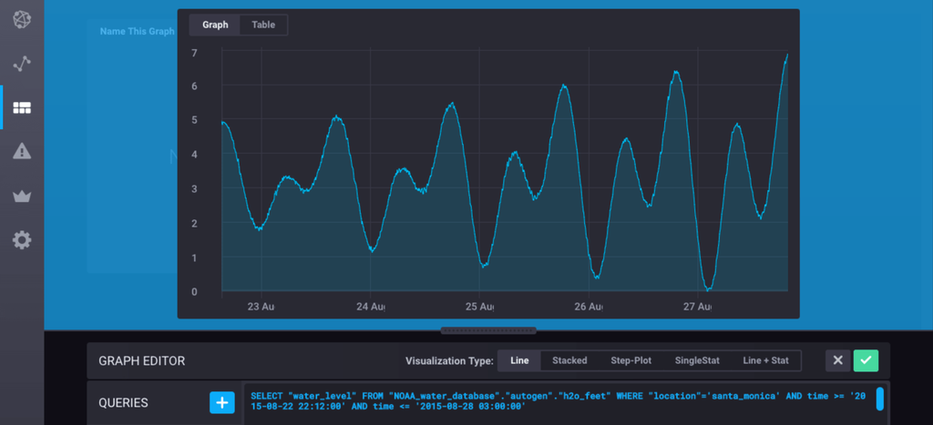

##### Step 1: Match the Trends of the Raw Data

Write a `GROUP BY time()` query that matches the general trends of the raw `water_level` data. Here, we use the `FIRST()` function:

```
SELECT FIRST("water_level") FROM "NOAA_water_database"."autogen"."h2o_feet" WHERE "location"='santa_monica' and time >= '2015-08-22 22:12:00' and time <= '2015-08-28 03:00:00' GROUP BY time(379m,348m)
```

In the `GROUP BY time()` clause, the first argument (`379m`) matches the length of time that occurs between each peak and trough in the `water_level` data. The second argument (`348m`) is the offset interval. The offset interval alters InfluxDB’s default `GROUP BY time()` boundaries to match the time range of the raw data.

The blue line shows the results of the query:

[figure not shown]

##### Step 2: Determine the Seasonal Pattern

Identify the seasonal pattern in the data using the information from the query in step 1.

Focusing on the blue line in the graph below, the pattern in the `water_level` data repeats about every 25 hours and 15 minutes. There are four data points per season, so `4` is the seasonal pattern argument.

[figure not shown]

##### Step 3: Apply the HOLT_WINTERS() function

Add the Holt-Winters function to the query. Here, we use `HOLT_WINTERS_WITH_FIT()` to view both the fitted values and the predicted values:

```
SELECT HOLT_WINTERS_WITH_FIT(FIRST("water_level"),10,4) FROM "NOAA_water_database"."autogen"."h2o_feet" WHERE "location"='santa_monica' AND time >= '2015-08-22 22:12:00' AND time <= '2015-08-28 03:00:00' GROUP BY time(379m,348m)
```

In the `HOLT_WINTERS_WITH_FIT()` function, the first argument (`10`) requests 10 predicted field values. Each predicted point is `379m` apart, the same interval as the first argument in the `GROUP BY time()` clause. The second argument in the `HOLT_WINTERS_WITH_FIT()` function (`4`) is the seasonal pattern that we determined in the previous step.

The blue line shows the results of the query:

[figure not shown]

### Common Issues with `HOLT_WINTERS()`

#### Issue 1: `HOLT_WINTERS()` and receiving fewer than `N` points

In some cases, users may receive fewer predicted points than requested by the `N` parameter. That behavior occurs when the math becomes unstable and cannot forecast more points. It implies that either `HOLT_WINTERS()` is not suited for the dataset or that the seasonal adjustment parameter is invalid and is confusing the algorithm.

# Other

## Sample Data

The data used in this document are available for download on the Sample Data page.

## General Syntax for Functions

### Specify Multiple Functions in the SELECT Clause

#### Syntax

```
SELECT <function>(),<function>() FROM_clause [...]
```

#### Description of Syntax

Separate multiple functions in one `SELECT` statement with a comma (`,`). The syntax applies to all InfluxQL functions except `TOP()` and `BOTTOM()`. The `SELECT` clause does not support specifying `TOP()` or `BOTTOM()` with another function.

#### Examples

##### Example 1: Calculate the mean and median field values in one query

```
> SELECT MEAN("water_level"),MEDIAN("water_level") FROM "h2o_feet"

name: h2o_feet
time                  mean               median
----                  ----               ------
1970-01-01T00:00:00Z  4.442107025822522  4.124
```

The query returns the average and median field values in the `water_level` field key.

##### Example 2: Calculate the mode of two fields in one query

```
> SELECT MODE("water_level"),MODE("level description") FROM "h2o_feet"

name: h2o_feet
time                  mode  mode_1
----                  ----  ------
1970-01-01T00:00:00Z  2.69  between 3 and 6 feet
```

The query returns the mode field values for the `water_level` field key and for the `level description` field key. The `water_level` mode is in the `mode` column and the `level description` mode is in the `mode_1` column. The system can’t return more than one column with the same name so it renames the second `mode` column to `mode_1`.

See Rename the Output Field Key for how to configure the output column headers.

##### Example 3: Calculate the minimum and maximum field values in one query

```
> SELECT MIN("water_level"), MAX("water_level") [...]

name: h2o_feet
time                  min    max
----                  ---    ---
1970-01-01T00:00:00Z  -0.61  9.964
```

The query returns the minimum and maximum field values in the `water_level` field key.

Notice that the query returns `1970-01-01T00:00:00Z`, InfluxDB’s null-timestamp equivalent, as the timestamp. `MIN()` and `MAX()` are selector functions; when a selector function is the only function in the `SELECT` clause, it returns a specific timestamp. Because `MIN()` and `MAX()` return two different timestamps (see below), the system overrides those timestamps with the null timestamp equivalent.

```
>  SELECT MIN("water_level") FROM "h2o_feet"

name: h2o_feet
time                  min
----                  ---
2015-08-29T14:30:00Z  -0.61    <--- Timestamp 1

>  SELECT MAX("water_level") FROM "h2o_feet"

name: h2o_feet
time                  max
----                  ---
2015-08-29T07:24:00Z  9.964    <--- Timestamp 2
```

### Rename the Output Field Key

#### Syntax

```
SELECT <function>() AS <field_key> [...]
```

#### Description of Syntax

By default, functions return results under a field key that matches the function name. Include an `AS` clause to specify the name of the output field key.

#### Examples

##### Example 1: Specify the output field key

```
> SELECT MEAN("water_level") AS "dream_name" FROM "h2o_feet"

name: h2o_feet
time                  dream_name
----                  ----------
1970-01-01T00:00:00Z  4.442107025822522
```

The query returns the average field value of the `water_level` field key and renames the output field key to `dream_name`. Without the `AS` clause, the query returns `mean` as the output field key:

```
> SELECT MEAN("water_level") FROM "h2o_feet"

name: h2o_feet
time                  mean
----                  ----
1970-01-01T00:00:00Z  4.442107025822522
```

##### Example 2: Specify the output field key for multiple functions

```
> SELECT MEDIAN("water_level") AS "med_wat",MODE("water_level") AS "mode_wat" FROM "h2o_feet"

name: h2o_feet
time                  med_wat  mode_wat
----                  -------  --------
1970-01-01T00:00:00Z  4.124    2.69
```

The query returns the median and mode field values for the `water_level` field key and renames the output field keys to `med_wat` and `mode_wat`. Without the `AS` clauses, the query returns `median` and `mode` as the output field keys:

```
> SELECT MEDIAN("water_level"),MODE("water_level") FROM "h2o_feet"

name: h2o_feet
time                  median  mode
----                  ------  ----
1970-01-01T00:00:00Z  4.124   2.69
```

### Change the Values Reported for Intervals with no Data

By default, queries with an InfluxQL function and a `GROUP BY time()` clause report null values for intervals with no data. Include `fill()` at the end of the `GROUP BY` clause to change that value. See Data Exploration for a complete discussion of `fill()`.

## Common Issues with Functions

The following sections describe frequent sources of confusion with all functions, aggregation functions, and selector functions. See the function-specific documentation for common issues with individual functions:

- DISTINCT()
- BOTTOM()
- PERCENTILE()
- SAMPLE()
- TOP()
- ELAPSED()
- HOLT_WINTERS()

### All Functions

#### Issue 1: Nesting functions

Some InfluxQL functions support nesting in the `SELECT` clause:

- `COUNT()` with `DISTINCT()`
- `CUMULATIVE_SUM()`
- `DERIVATIVE()`
- `DIFFERENCE()`
- `ELAPSED()`
- `MOVING_AVERAGE()`
- `NON_NEGATIVE_DERIVATIVE()`
- `HOLT_WINTERS()` and `HOLT_WINTERS_WITH_FIT()`

For other functions, use InfluxQL’s subqueries to nest functions in the `FROM` clause. See the Data Exploration page more on using subqueries.

#### Issue 2: Querying time ranges after now()

Most `SELECT` statements have a default time range between `1677-09-21 00:12:43.145224194` and `2262-04-11T23:47:16.854775806Z` UTC. For `SELECT` statements with an InfluxQL function and a `GROUP BY time()` clause, the default time range is between `1677-09-21 00:12:43.145224194` UTC and `now()`.

To query data with timestamps that occur after `now()`, `SELECT` statements with an InfluxQL function and a `GROUP BY time()` clause must provide an alternative upper bound in the `WHERE` clause. See the Frequently Asked Questions page for an example.

### Aggregation Functions

#### Issue 1: Understanding the returned timestamp

A query with an aggregation function and no time range in the `WHERE` clause returns epoch 0 (`1970-01-01T00:00:00Z`) as the timestamp. InfluxDB uses epoch 0 as the null timestamp equivalent. A query with an aggregate function that includes a time range in the `WHERE` clause returns the lower time bound as the timestamp.

##### Example 1: Use an aggregate function without a specified time range

```
> SELECT SUM("water_level") FROM "h2o_feet"

name: h2o_feet
time                   sum
----                   ---
1970-01-01T00:00:00Z   67777.66900000004
```

The query returns InfluxDB’s null timestamp equivalent (epoch 0: `1970-01-01T00:00:00Z`) as the timestamp. `SUM()` aggregates points across several timestamps and has no single timestamp to return.

##### Example 2: Use an aggregate function with a specified time range

```
> SELECT SUM("water_level") FROM "h2o_feet" WHERE time >= '2015-08-18T00:00:00Z'

name: h2o_feet
time                  sum
----                  ---
2015-08-18T00:00:00Z  67777.66900000004
```

The query returns the lower time bound (`WHERE time >= '2015-08-18T00:00:00Z'`) as the timestamp.

##### Example 3: Use an aggregate function with a specified time range and a GROUP BY time() clause

```
> SELECT SUM("water_level") FROM "h2o_feet" WHERE time >= '2015-08-18T00:00:00Z' AND time <= '2015-08-18T00:18:00Z' GROUP BY time(12m)

name: h2o_feet
time                  sum
----                  ---
2015-08-18T00:00:00Z  20.305
2015-08-18T00:12:00Z  19.802999999999997
```

The query returns the lower time bound for each `GROUP BY time()` interval as the timestamps.

#### Issue 2: Mixing aggregation functions with non-aggregates

Aggregation functions do not support specifying standalone field keys or tag keys in the `SELECT` clause. Aggregation functions return a single calculated value and there is no obvious single value to return for any unaggregated fields or tags. Including a standalone field key or tag key with an aggregation function in the `SELECT` clause returns an error:

```
> SELECT SUM("water_level"),"location" FROM "h2o_feet"

ERR: error parsing query: mixing aggregate and non-aggregate queries is not supported
```

#### Issue 3: Getting slightly different results

For some aggregation functions, executing the same function on the same set of float64 points may yield slightly different results. InfluxDB does not sort points before it applies the aggregation function; that behavior can cause small discrepancies in the query results.

### Selector Functions

#### Issue 1: Understanding the returned timestamp

The timestamps returned by selector functions depend on the number of functions in the query and on the other clauses in the query:

A query with a single selector function, a single field key argument, and no `GROUP BY time()` clause returns the timestamp for the point that appears in the raw data. A query with a single selector function, multiple field key arguments, and no `GROUP BY time()` clause returns the timestamp for the point that appears in the raw data or InfluxDB’s null timestamp equivalent (epoch 0: `1970-01-01T00:00:00Z`).

A query with more than one function and no time range in the `WHERE` clause returns InfluxDB’s null timestamp equivalent (epoch 0: `1970-01-01T00:00:00Z`). A query with more than one function and a time range in the `WHERE` clause returns the lower time bound as the timestamp.

A query with a selector function and a `GROUP BY time()` clause returns the lower time bound for each `GROUP BY time()` interval. Note that the `SAMPLE()` function behaves differently from other selector functions when paired with the `GROUP BY time()` clause. See Common Issues with `SAMPLE()` for more information.

##### Example 1: Use a single selector function with a single field key and without a specified time range

```
> SELECT MAX("water_level") FROM "h2o_feet"

name: h2o_feet
time                  max
----                  ---
2015-08-29T07:24:00Z  9.964

> SELECT MAX("water_level") FROM "h2o_feet" WHERE time >= '2015-08-18T00:00:00Z'

name: h2o_feet
time                  max
----                  ---
2015-08-29T07:24:00Z  9.964
```

The queries return the timestamp for the maximum point that appears in the raw data.

##### Example 2: Use a single selector function with multiple field keys and without a specified time range

```
> SELECT FIRST(*) FROM "h2o_feet"

name: h2o_feet
time                  first_level description  first_water_level
----                  -----------------------  -----------------
1970-01-01T00:00:00Z  between 6 and 9 feet     8.12

> SELECT MAX(*) FROM "h2o_feet"

name: h2o_feet
time                  max_water_level
----                  ---------------
2015-08-29T07:24:00Z  9.964
```

The first query returns InfluxDB’s null timestamp equivalent (epoch 0: `1970-01-01T00:00:00Z`) as the timestamp. `FIRST(*)` returns two timestamps (one for each field key in the `h2o_feet` measurement) so the system overrides those timestamps with the null timestamp equivalent.

The second query returns the timestamp for the maximum point that appears in the raw data. `MAX(*)` returns one timestamp (the `h2o-feet` measurement has only one numerical field) so the system does not overwrite the original timestamp.

##### Example 3: Use a selector function with another function and without a specified time range

```
> SELECT MAX("water_level"),MIN("water_level") FROM "h2o_feet"

name: h2o_feet
time                  max    min
----                  ---    ---
1970-01-01T00:00:00Z  9.964  -0.61
```

The query returns InfluxDB’s null timestamp equivalent (epoch 0: `1970-01-01T00:00:00Z`) as the timestamp. The `MAX()` and `MIN()` functions return different timestamps so the system has no single timestamp to return.

##### Example 4: Use a selector function with another function and with a specified time range

```
> SELECT MAX("water_level"),MIN("water_level") FROM "h2o_feet" WHERE time >= '2015-08-18T00:00:00Z'

name: h2o_feet
time                  max    min
----                  ---    ---
2015-08-18T00:00:00Z  9.964  -0.61
```

The query returns the lower time bound (`WHERE time >= '2015-08-18T00:00:00Z'`) as the timestamp.

##### Example 5: Use a selector function with a GROUP BY time() clause

```
> SELECT MAX("water_level") FROM "h2o_feet" WHERE time >= '2015-08-18T00:00:00Z' AND time <= '2015-08-18T00:18:00Z' GROUP BY time(12m)

name: h2o_feet
time                  max
----                  ---
2015-08-18T00:00:00Z  8.12
2015-08-18T00:12:00Z  7.887
```

The query returns the lower time bound for each `GROUP BY time()` interval as the timestamp.

© 2015 InfluxData, Inc.  
Licensed under the MIT license.  
https://docs.influxdata.com/influxdb/v1.3/query_language/functions/